# G Luku 1 Yksinkertainen korrespondenssianalyysi

```r
str(ISSP2012jh1d.dat)
```

```
## Classes 'tbl_df', 'tbl' and 'data.frame':    32823 obs. of  27 variables:
##  $ V1      : 'haven_labelled' num  5900 5900 5900 5900 5900 5900 5900 5900 5900 5900 ...
##   ..- attr(*, "label")= chr "GESIS Data Archive Study Number"
##   ..- attr(*, "labels")= Named num 5900
##   .. ..- attr(*, "names")= chr "GESIS Data Archive Study Number ZA5900"
##  $ V2      : chr  "4.0.0 (2016-11-23)" "4.0.0 (2016-11-23)" "4.0.0 (2016-11-23)" "4.0.0 (2016-11-23)" ...
##   ..- attr(*, "label")= chr "GESIS Archive Version"
##   ..- attr(*, "format.spss")= chr "A25"
##   ..- attr(*, "display_width")= int 26
##  $ DOI     : chr  "doi:10.4232/1.12661" "doi:10.4232/1.12661" "doi:10.4232/1.12661" "doi:10.4232/1.12661" ...
##   ..- attr(*, "label")= chr "Digital Object Identifier"
##   ..- attr(*, "format.spss")= chr "A50"
##   ..- attr(*, "display_width")= int 26
##  $ V3      : 'haven_labelled' num  36 36 36 36 36 36 36 36 36 36 ...
##   ..- attr(*, "label")= chr "Country/ Sample ISO 3166 Code (see V4 for codes for whole nation states)"
##   ..- attr(*, "labels")= Named num  32 36 40 100 124 152 156 158 191 203 ...
##   .. ..- attr(*, "names")= chr  "AR-Argentina" "AU-Australia" "AT-Austria" "BG-Bulgaria" ...
##  $ V4      : 'haven_labelled' num  36 36 36 36 36 36 36 36 36 36 ...
##   ..- attr(*, "label")= chr "Country ISO 3166 Code (see V3 for codes for the sample)"
##   ..- attr(*, "labels")= Named num  32 36 40 56 100 124 152 156 158 191 ...
##   .. ..- attr(*, "names")= chr  "AR-Argentina" "AU-Australia" "AT-Austria" "BE-Belgium" ...
##  $ C_ALPHAN: chr  "AU" "AU" "AU" "AU" ...
##   ..- attr(*, "label")= chr "Country Prefix ISO 3166 Code - alphanumeric"
##   ..- attr(*, "format.spss")= chr "A20"
##   ..- attr(*, "display_width")= int 22
##  $ V5      : 'haven_labelled' num  5 1 2 2 1 NA 2 4 2 2 ...
##   ..- attr(*, "label")= chr "Q1a Working mom: warm relationship with children as a not working mom"
##   ..- attr(*, "labels")= Named num  0 1 2 3 4 5 8 9
##   .. ..- attr(*, "names")= chr  "NAP: ES" "Strongly agree" "Agree" "Neither agree nor disagree" ...
##  $ V6      : 'haven_labelled' num  1 5 4 4 4 NA 4 3 4 3 ...
##   ..- attr(*, "label")= chr "Q1b Working mom: Preschool child is likely to suffer"
##   ..- attr(*, "labels")= Named num  0 1 2 3 4 5 8 9
##   .. ..- attr(*, "names")= chr  "NAP: ES" "Strongly agree" "Agree" "Neither agree nor disagree" ...
##  $ V7      : 'haven_labelled' num  3 5 2 4 4 NA 4 2 4 2 ...
##   ..- attr(*, "label")= chr "Q1c Working woman: Family life suffers when woman has full-time job"
##   ..- attr(*, "labels")= Named num  0 1 2 3 4 5 8 9
##   .. ..- attr(*, "names")= chr  "NAP: ES" "Strongly agree" "Agree" "Neither agree nor disagree" ...
##  $ V8      : 'haven_labelled' num  3 5 5 2 4 NA 4 5 4 5 ...
##   ..- attr(*, "label")= chr "Q1d Working woman: What women really want is home and kids"
##   ..- attr(*, "labels")= Named num  0 1 2 3 4 5 8 9
```

[output cut: 48 more lines]

```
##   .. ..- attr(*, "names")= chr  "Married" "Civil partnership" "Separated from spouse/ civil partner (still legally married/ still legally in a civil partnership)" "Divorced from spouse/ legally separated from civil partner" ...
##  $ URBRURAL: 'haven_labelled' num  1 1 1 NA 1 2 NA 2 2 NA ...
##   ..- attr(*, "label")= chr "Place of living: urban - rural"
##   ..- attr(*, "labels")= Named num  1 2 3 4 5 7 9
##   .. ..- attr(*, "names")= chr  "A big city" "The suburbs or outskirts of a big city" "A town or a small city" "A country village" ...
##  $ maa     : Factor w/ 25 levels "AU","AT","BG",..: 1 1 1 1 1 1 1 1 1 1 ...
##   ..- attr(*, "label")= chr "Country Prefix ISO 3166 Code - alphanumeric"
##  $ sp1     : Factor w/ 3 levels "Male","Female",..: 1 2 2 2 2 1 2 1 2 2 ...
##   ..- attr(*, "label")= chr "Sex of Respondent"
##  $ sp      : Factor w/ 2 levels "m","f": 1 2 2 2 2 1 2 1 2 2 ...
##   ..- attr(*, "label")= chr "Sex of Respondent"
##  $ ika     : 'haven_labelled' num  58 59 40 20 72 68 64 57 45 71 ...
##   ..- attr(*, "label")= chr "Age of respondent"
##   ..- attr(*, "labels")= Named num  15 16 17 18 102 999
##   .. ..- attr(*, "names")= chr  "15 years" "16 years" "17 years" "18 years" ...
```

Vaihessa 2 luodaan samalla samalla periaatteella substanssi- ja taustamuuttujille kaksi R-factor- tyypin muuttujaa. Toisessa (esim. Q1a) puuttuva tieto on R-ohjelmiston sisäinen NA-arvo. Toisessa (Q1am) puuttuva tieto on yksi luokittelumuuttujan arvo(“missing”).

```r
# Substanssi- ja taustamuuttujat R-faktoreiksi
ISSP2012jh1d.dat <- ISSP2012jh1d.dat %>%
    mutate(Q1a1 = as_factor(V5), #labels
            Q1b1 = as_factor(V6),
            Q1c1 = as_factor(V7),
            Q1d1 = as_factor(V8),
            Q1e1 = as_factor(V9),
            Q2a1 = as_factor(V10),
            Q2b1 = as_factor(V11),
            Q3a1 = as_factor(V12), #labels = vastQ3_labels (W,w,H)
            Q3b1 = as_factor(V13), #labels = vastQ3_labels
            edu1 = as_factor(DEGREE),
            msta1= as_factor(MAINSTAT),
            sosta1 = as_factor(TOPBOT),
            nchild1 = as_factor(HHCHILDR),
            lifsta1 = as_factor(MARITAL),
            urbru1 = as_factor(URBRURAL)

    )

# Muuttujat Q1a1...urbru1 ovat apumuuttujia, joissa on periaatteessa kaikki SPSS-
# tiedostosta siirtyvä metatieto. Poikkeus on SPSS:n kolme tarkentavaa koodia
# puuttuvalle tiedolle, ne saisi mukaan read_spss - parametrin avulla (user_na=TRUE)
#

# Tarkistusksia
ISSP2012jh1d.dat %>% summary()
```

|  | V1 | V2 | DOI | V3 | V4 C | _ALPHAN | V5 | V6 | V7 | V8 | V9 | V10 | V11 | V12 | V13 | SEX | AGE | DEGREE | MAINSTAT | TOPBOT | HHCHILDR | MARITAL | URBRURAL | maa | sp1 sp |  | ika | Q1a1 | Q1b1 | … |
| --- | --- | --- | --- | --- | --- | --- | --- | --- | --- | --- | --- | --- | --- | --- | --- | --- | --- | --- | --- | --- | --- | --- | --- | --- | --- | --- | --- | --- | --- | --- |
|  | Min. :5900 | Length:32823 | Length:32823 | Min. : 36 | Min. : 36.0 | Length:32823 | Min. :1.000 | Min. :1.000 | Min. :1.000 | Min. :1.000 | Min. :1.000 | Min. :1.000 | Min. :1.000 | Min. :1.000 | Min. :1.000 | Min. :1.000 | Min. : 15.00 | Min. :0.00 | Min. :1.000 | Min. : 1.00 | Min. : 0.0000 | Min. :1.000 | Min. :1.000 | FR : 2409 | Male :14789 | m:14789 | Min. : 15.00 | Agree :12352 | Disagree :9003 | … |
|  | 1st Qu.:5900 | Class :character | Class :character | 1st Qu.: 208 | 1st Qu.:203.0 | Class :character | 1st Qu.:1.000 | 1st Qu.:2.000 | 1st Qu.:2.000 | 1st Qu.:2.000 | 1st Qu.:2.000 | 1st Qu.:1.000 | 1st Qu.:3.000 | 1st Qu.:2.000 | 1st Qu.:1.000 | 1st Qu.:1.000 | 1st Qu.: 36.00 | 1st Qu.:2.00 | 1st Qu.:1.000 | 1st Qu.: 5.00 | 1st Qu.: 0.0000 | 1st Qu.:1.000 | 1st Qu.:1.000 | BE : 2192 | Female :18034 | f:18034 | 1st Qu.: 36.00 | Strongly agree :11116 | Agree :8389 | … |
|  | Median :5900 | Mode :character | Mode :character | Median : 428 | Median :276.0 | Mode :character | Median :2.000 | Median :3.000 | Median :3.000 | Median :3.000 | Median :3.000 | Median :2.000 | Median :4.000 | Median :2.000 | Median :2.000 | Median :2.000 | Median : 50.00 | Median :3.00 | Median :1.000 | Median : 6.00 | Median : 0.0000 | Median :1.000 | Median :3.000 | CZ : 1804 | No answer: 0 | NA | Median : 50.00 | Disagree : 4074 | Neither agree nor disagree:5949 | … |
|  | Mean :5900 | NA | NA | Mean : 4063 | Mean :362.1 | NA | Mean :2.112 | Mean :3.196 | Mean :3.211 | Mean :3.149 | Mean :2.971 | Mean :1.963 | Mean :3.513 | Mean :2.102 | Mean :1.592 | Mean :1.549 | Mean : 49.52 | Mean :3.55 | Mean :2.887 | Mean : 5.68 | Mean : 0.3832 | Mean :2.844 | Mean :2.729 | DE : 1761 | NA | NA | Mean : 49.52 | Neither agree nor disagree: 3382 | Strongly disagree :5547 | … |
|  | 3rd Qu.:5900 | NA | NA | 3rd Qu.: 705 | 3rd Qu.:578.0 | NA | 3rd Qu.:3.000 | 3rd Qu.:4.000 | 3rd Qu.:4.000 | 3rd Qu.:4.000 | 3rd Qu.:4.000 | 3rd Qu.:2.000 | 3rd Qu.:5.000 | 3rd Qu.:3.000 | 3rd Qu.:2.000 | 3rd Qu.:2.000 | 3rd Qu.: 63.00 | 3rd Qu.:5.00 | 3rd Qu.:6.000 | 3rd Qu.: 7.00 | 3rd Qu.: 0.0000 | 3rd Qu.:5.000 | 3rd Qu.:4.000 | AU : 1557 | NA | NA | 3rd Qu.: 63.00 | Strongly disagree : 1051 | Strongly agree :2747 | … |
|  | Max. :5900 | NA | NA | Max. :62002 | Max. :756.0 | NA | Max. :5.000 | Max. :5.000 | Max. :5.000 | Max. :5.000 | Max. :5.000 | Max. :5.000 | Max. :5.000 | Max. :3.000 | Max. :3.000 | Max. :2.000 | Max. :102.00 | Max. :6.00 | Max. :9.000 | Max. :10.00 | Max. :21.0000 | Max. :6.000 | Max. :5.000 | RU : 1525 | NA | NA | Max. :102.00 | (Other) : 0 | (Other) : 0 | … |
|  | NA | NA | NA | NA | NA | NA | NA’s :848 | NA’s :1188 | NA’s :1056 | NA’s :2051 | NA’s :2554 | NA’s :683 | NA’s :719 | NA’s :3428 | NA’s :3522 | NA | NA | NA’s :308 | NA’s :370 | NA’s :1777 | NA’s :940 | NA’s :434 | NA’s :244 | (Other):21575 | NA | NA | NA | NA’s : 848 | NA’s :1188 | … |

```r
# Substanssimuuttujat

ISSP2012jh1d.dat$Q1a1 %>% fct_count()
```

| f | n |
| --- | --- |
| NAP: ES | 0 |
| Strongly agree | 11116 |
| Agree | 12352 |
| Neither agree nor disagree | 3382 |
| Disagree | 4074 |
| Strongly disagree | 1051 |
| Can’t choose, CA:+NA, KR:DK,ref., NL:DK | 0 |
| No answer | 0 |
| NA | 848 |

```r
ISSP2012jh1d.dat$Q1b1 %>% fct_count()
```

| f | n |
| --- | --- |
| NAP: ES | 0 |
| Strongly agree | 2747 |
| Agree | 8389 |
| Neither agree nor disagree | 5949 |
| Disagree | 9003 |
| Strongly disagree | 5547 |
| Can’t choose, CA:+NA, KR:DK,ref., NL:DK | 0 |
| No answer | 0 |
| NA | 1188 |

```r
ISSP2012jh1d.dat$Q1c1 %>% fct_count()
```

| f | n |
| --- | --- |
| NAP: ES | 0 |
| Strongly agree | 2838 |
| Agree | 8263 |
| Neither agree nor disagree | 6000 |
| Disagree | 8706 |
| Strongly disagree | 5960 |
| Can’t choose, CA:+NA, KR:DK,ref., NL:DK | 0 |
| No answer | 0 |
| NA | 1056 |

```r
ISSP2012jh1d.dat$Q1d1 %>% fct_count()
```

| f | n |
| --- | --- |
| NAP: ES | 0 |
| Strongly agree | 2818 |
| Agree | 7672 |
| Neither agree nor disagree | 7403 |
| Disagree | 7863 |
| Strongly disagree | 5016 |
| Can’t choose, CA:+NA, KR:DK,ref., NL:DK | 0 |
| No answer | 0 |
| NA | 2051 |

```r
ISSP2012jh1d.dat$Q1e1 %>% fct_count()
```

| f | n |
| --- | --- |
| NAP: ES | 0 |
| Strongly agree | 3357 |
| Agree | 8342 |
| Neither agree nor disagree | 7841 |
| Disagree | 7267 |
| Strongly disagree | 3462 |
| Can’t choose, CA:+NA, KR:DK,ref., NL:DK | 0 |
| No answer | 0 |
| NA | 2554 |

```r
ISSP2012jh1d.dat$Q2a1 %>% fct_count()
```

| f | n |
| --- | --- |
| NAP: ES | 0 |
| Strongly agree | 11305 |
| Agree | 13464 |
| Neither agree nor disagree | 5039 |
| Disagree | 1929 |
| Strongly disagree | 403 |
| Can’t choose, CA:+NA, KR:DK,ref., NL:DK | 0 |
| No answer | 0 |
| NA | 683 |

```r
ISSP2012jh1d.dat$Q2b1 %>% fct_count()
```

| f | n |
| --- | --- |
| NAP: ES | 0 |
| Strongly agree | 2704 |
| Agree | 5164 |
| Neither agree nor disagree | 6109 |
| Disagree | 9210 |
| Strongly disagree | 8917 |
| Can’t choose, CA:+NA, KR:DK,ref., NL:DK | 0 |
| No answer | 0 |
| NA | 719 |

```r
ISSP2012jh1d.dat$Q3a1 %>% fct_count()
```

| f | n |
| --- | --- |
| Work full-time | 5373 |
| Work part-time | 15655 |
| Stay at home | 8367 |
| TW: women should decide | 0 |
| Can’t choose, CA:+NA, KR:DK,ref., NL:DK | 0 |
| No answer | 0 |
| NA | 3428 |

```r
ISSP2012jh1d.dat$Q3b1 %>% fct_count()
```

| f | n |
| --- | --- |
| Work full-time | 13722 |
| Work part-time | 13817 |
| Stay at home | 1762 |
| TW: women should decide | 0 |
| Can’t choose, CA:+NA, KR:DK,ref., NL:DK | 0 |
| No answer | 0 |
| NA | 3522 |

```r
# Taustamuuttujat

ISSP2012jh1d.dat$edu1 %>% fct_count()
```

| f | n |
| --- | --- |
| No formal education | 491 |
| Primary school (elementary school) | 1531 |
| Lower secondary (secondary completed does not allow entry to university: obligatory school) | 7811 |
| Upper secondary (programs that allows entry to university | 7115 |
| Post secondary, non-tertiary (other upper secondary programs toward labour market or technical formation) | 5658 |
| Lower level tertiary, first stage (also technical schools at a tertiary level) | 5147 |
| Upper level tertiary (Master, Dr.) | 4762 |
| No answer, CH: don’t know | 0 |
| NA | 308 |

```r
ISSP2012jh1d.dat$msta1 %>% fct_count()
```

| f | n |
| --- | --- |
| In paid work | 17967 |
| Unemployed and looking for a job, HR: incl never had a job | 1769 |
| In education | 1763 |
| Apprentice or trainee | 189 |
| Permanently sick or disabled | 1093 |
| Retired | 7999 |
| Domestic work | 1180 |
| In compulsory military service or community service | 9 |
| Other | 484 |
| No answer | 0 |
| NA | 370 |

```r
ISSP2012jh1d.dat$sosta1 %>% fct_count()
```

| f | n |
| --- | --- |
| Not available: GB,US | 0 |
| Lowest, Bottom, 01 | 562 |
| 02 | 866 |
| 03 | 2221 |
| 04 | 3346 |
| 05 | 6798 |
| 06 | 6889 |
| 07 | 5778 |
| 08 | 3477 |
| 09 | 667 |
| Highest, Top, 10 | 442 |
| Refused | 0 |
| Don’t know | 0 |
| No answer | 0 |
| NA | 1777 |

```r
ISSP2012jh1d.dat$nchild1 %>% fct_count()
```

| f | n |
| --- | --- |
| No children | 24102 |
| One child | 4378 |
| 2 children | 2643 |
| 3 | 598 |
| 4 | 117 |
| 5 | 20 |
| 6 | 13 |
| 7 | 7 |
| 8 | 3 |
| 18 | 1 |
| 21 children | 1 |
| NAP (Code 0 in HOMPOP); not available: TR | 0 |
| Refused | 0 |
| No answer | 0 |
| NA | 940 |

```r
ISSP2012jh1d.dat$lifsta1 %>% fct_count()
```

| f | n |
| --- | --- |
| Married | 17573 |
| Civil partnership | 1035 |
| Separated from spouse/ civil partner (still legally married/ still legally in a civil partnership) | 486 |
| Divorced from spouse/ legally separated from civil partner | 2997 |
| Widowed/ civil partner died | 2763 |
| Never married/ never in a civil partnership, single | 7535 |
| Refused | 0 |
| Don’t know | 0 |
| No answer | 0 |
| NA | 434 |

```r
ISSP2012jh1d.dat$urbru1 %>% fct_count()
```

| f | n |
| --- | --- |
| A big city | 8442 |
| The suburbs or outskirts of a big city | 4386 |
| A town or a small city | 9203 |
| A country village | 8646 |
| A farm or home in the country | 1902 |
| Other answer | 0 |
| No answer | 0 |
| NA | 244 |

Taustamuuttujien luokitteluja (esim. luokkien yhdistäminen) pohditaan tarkemmin, kun muuttujat otetaan käyttöön.

Poistetaan muuuttujista luokittelumuuttujien arvot, joissa ei ole havaintoja. Näitä tyhjiä luokkia siirtyy SPSS-tiedostosta haven_labelled -luokan tietohin.

```r
# Poistetaan tyhjät luokat muuttujista

ISSP2012jh1d.dat <- ISSP2012jh1d.dat %>%
    mutate(Q1a = fct_drop(Q1a1),
           Q1b = fct_drop(Q1b1),
           Q1c = fct_drop(Q1c1),
           Q1d = fct_drop(Q1d1),
           Q1e = fct_drop(Q1e1),
           Q2a = fct_drop(Q2a1),
           Q2b = fct_drop(Q2b1),
           Q3a = fct_drop(Q3a1),
           Q3b = fct_drop(Q3b1),
           edu = fct_drop(edu1),
           msta = fct_drop(msta1),
           sosta = fct_drop(sosta1),
           nchild = fct_drop(nchild1),
           lifsta = fct_drop(lifsta1),
           urbru = fct_drop(urbru1)

    )
# Tarkistuksia 1

ISSP2012jh1d.dat %>% summary()
```

|  | V1 | V2 | DOI | V3 | V4 C | _ALPHAN | V5 | V6 | V7 | V8 | V9 | V10 | V11 | V12 | V13 | SEX | AGE | DEGREE | MAINSTAT | TOPBOT | HHCHILDR | MARITAL | URBRURAL | maa | sp1 sp |  | ika | Q1a1 | Q1b1 | … |
| --- | --- | --- | --- | --- | --- | --- | --- | --- | --- | --- | --- | --- | --- | --- | --- | --- | --- | --- | --- | --- | --- | --- | --- | --- | --- | --- | --- | --- | --- | --- |
|  | Min. :5900 | Length:32823 | Length:32823 | Min. : 36 | Min. : 36.0 | Length:32823 | Min. :1.000 | Min. :1.000 | Min. :1.000 | Min. :1.000 | Min. :1.000 | Min. :1.000 | Min. :1.000 | Min. :1.000 | Min. :1.000 | Min. :1.000 | Min. : 15.00 | Min. :0.00 | Min. :1.000 | Min. : 1.00 | Min. : 0.0000 | Min. :1.000 | Min. :1.000 | FR : 2409 | Male :14789 | m:14789 | Min. : 15.00 | Agree :12352 | Disagree :9003 | … |
|  | 1st Qu.:5900 | Class :character | Class :character | 1st Qu.: 208 | 1st Qu.:203.0 | Class :character | 1st Qu.:1.000 | 1st Qu.:2.000 | 1st Qu.:2.000 | 1st Qu.:2.000 | 1st Qu.:2.000 | 1st Qu.:1.000 | 1st Qu.:3.000 | 1st Qu.:2.000 | 1st Qu.:1.000 | 1st Qu.:1.000 | 1st Qu.: 36.00 | 1st Qu.:2.00 | 1st Qu.:1.000 | 1st Qu.: 5.00 | 1st Qu.: 0.0000 | 1st Qu.:1.000 | 1st Qu.:1.000 | BE : 2192 | Female :18034 | f:18034 | 1st Qu.: 36.00 | Strongly agree :11116 | Agree :8389 | … |
|  | Median :5900 | Mode :character | Mode :character | Median : 428 | Median :276.0 | Mode :character | Median :2.000 | Median :3.000 | Median :3.000 | Median :3.000 | Median :3.000 | Median :2.000 | Median :4.000 | Median :2.000 | Median :2.000 | Median :2.000 | Median : 50.00 | Median :3.00 | Median :1.000 | Median : 6.00 | Median : 0.0000 | Median :1.000 | Median :3.000 | CZ : 1804 | No answer: 0 | NA | Median : 50.00 | Disagree : 4074 | Neither agree nor disagree:5949 | … |
|  | Mean :5900 | NA | NA | Mean : 4063 | Mean :362.1 | NA | Mean :2.112 | Mean :3.196 | Mean :3.211 | Mean :3.149 | Mean :2.971 | Mean :1.963 | Mean :3.513 | Mean :2.102 | Mean :1.592 | Mean :1.549 | Mean : 49.52 | Mean :3.55 | Mean :2.887 | Mean : 5.68 | Mean : 0.3832 | Mean :2.844 | Mean :2.729 | DE : 1761 | NA | NA | Mean : 49.52 | Neither agree nor disagree: 3382 | Strongly disagree :5547 | … |
|  | 3rd Qu.:5900 | NA | NA | 3rd Qu.: 705 | 3rd Qu.:578.0 | NA | 3rd Qu.:3.000 | 3rd Qu.:4.000 | 3rd Qu.:4.000 | 3rd Qu.:4.000 | 3rd Qu.:4.000 | 3rd Qu.:2.000 | 3rd Qu.:5.000 | 3rd Qu.:3.000 | 3rd Qu.:2.000 | 3rd Qu.:2.000 | 3rd Qu.: 63.00 | 3rd Qu.:5.00 | 3rd Qu.:6.000 | 3rd Qu.: 7.00 | 3rd Qu.: 0.0000 | 3rd Qu.:5.000 | 3rd Qu.:4.000 | AU : 1557 | NA | NA | 3rd Qu.: 63.00 | Strongly disagree : 1051 | Strongly agree :2747 | … |
|  | Max. :5900 | NA | NA | Max. :62002 | Max. :756.0 | NA | Max. :5.000 | Max. :5.000 | Max. :5.000 | Max. :5.000 | Max. :5.000 | Max. :5.000 | Max. :5.000 | Max. :3.000 | Max. :3.000 | Max. :2.000 | Max. :102.00 | Max. :6.00 | Max. :9.000 | Max. :10.00 | Max. :21.0000 | Max. :6.000 | Max. :5.000 | RU : 1525 | NA | NA | Max. :102.00 | (Other) : 0 | (Other) : 0 | … |
|  | NA | NA | NA | NA | NA | NA | NA’s :848 | NA’s :1188 | NA’s :1056 | NA’s :2051 | NA’s :2554 | NA’s :683 | NA’s :719 | NA’s :3428 | NA’s :3522 | NA | NA | NA’s :308 | NA’s :370 | NA’s :1777 | NA’s :940 | NA’s :434 | NA’s :244 | (Other):21575 | NA | NA | NA | NA’s : 848 | NA’s :1188 | … |

```r
ISSP2012jh1d.dat %>%
    select(Q1a, Q1b, Q1c, Q1d, Q1e,Q2a,Q2b,Q3a, Q3b) %>%
    str()
```

```
## Classes 'tbl_df', 'tbl' and 'data.frame':    32823 obs. of  9 variables:
##  $ Q1a: Factor w/ 5 levels "Strongly agree",..: 5 1 2 2 1 NA 2 4 2 2 ...
##   ..- attr(*, "label")= chr "Q1a Working mom: warm relationship with children as a not working mom"
##  $ Q1b: Factor w/ 5 levels "Strongly agree",..: 1 5 4 4 4 NA 4 3 4 3 ...
##   ..- attr(*, "label")= chr "Q1b Working mom: Preschool child is likely to suffer"
##  $ Q1c: Factor w/ 5 levels "Strongly agree",..: 3 5 2 4 4 NA 4 2 4 2 ...
##   ..- attr(*, "label")= chr "Q1c Working woman: Family life suffers when woman has full-time job"
##  $ Q1d: Factor w/ 5 levels "Strongly agree",..: 3 5 5 2 4 NA 4 5 4 5 ...
##   ..- attr(*, "label")= chr "Q1d Working woman: What women really want is home and kids"
##  $ Q1e: Factor w/ 5 levels "Strongly agree",..: 3 1 2 3 4 NA 2 4 4 1 ...
##   ..- attr(*, "label")= chr "Q1e Working woman: Being housewife is as fulfilling as working for pay"
##  $ Q2a: Factor w/ 5 levels "Strongly agree",..: 1 3 4 2 2 NA 2 5 2 1 ...
##   ..- attr(*, "label")= chr "Q2a Both should contribute to household income"
##  $ Q2b: Factor w/ 5 levels "Strongly agree",..: 3 5 4 4 4 NA 2 5 4 1 ...
##   ..- attr(*, "label")= chr "Q2b Men's job earn money, women's job look after home"
##  $ Q3a: Factor w/ 3 levels "Work full-time",..: 3 NA NA 2 2 NA 2 NA 2 2 ...
##   ..- attr(*, "label")= chr "Q3a Should women work: Child under school age"
##  $ Q3b: Factor w/ 3 levels "Work full-time",..: 2 NA 2 1 2 NA 2 NA 2 2 ...
##   ..- attr(*, "label")= chr "Q3b Should women work: Youngest kid at school"
```

```r
ISSP2012jh1d.dat %>%
    select(Q1a1, Q1b1, Q1c1, Q1d1, Q1e1,Q2a1,Q2b1,Q3a1, Q3b1) %>%
    str()
```

```
## Classes 'tbl_df', 'tbl' and 'data.frame':    32823 obs. of  9 variables:
##  $ Q1a1: Factor w/ 8 levels "NAP: ES","Strongly agree",..: 6 2 3 3 2 NA 3 5 3 3 ...
##   ..- attr(*, "label")= chr "Q1a Working mom: warm relationship with children as a not working mom"
##  $ Q1b1: Factor w/ 8 levels "NAP: ES","Strongly agree",..: 2 6 5 5 5 NA 5 4 5 4 ...
##   ..- attr(*, "label")= chr "Q1b Working mom: Preschool child is likely to suffer"
##  $ Q1c1: Factor w/ 8 levels "NAP: ES","Strongly agree",..: 4 6 3 5 5 NA 5 3 5 3 ...
##   ..- attr(*, "label")= chr "Q1c Working woman: Family life suffers when woman has full-time job"
##  $ Q1d1: Factor w/ 8 levels "NAP: ES","Strongly agree",..: 4 6 6 3 5 NA 5 6 5 6 ...
##   ..- attr(*, "label")= chr "Q1d Working woman: What women really want is home and kids"
##  $ Q1e1: Factor w/ 8 levels "NAP: ES","Strongly agree",..: 4 2 3 4 5 NA 3 5 5 2 ...
##   ..- attr(*, "label")= chr "Q1e Working woman: Being housewife is as fulfilling as working for pay"
##  $ Q2a1: Factor w/ 8 levels "NAP: ES","Strongly agree",..: 2 4 5 3 3 NA 3 6 3 2 ...
##   ..- attr(*, "label")= chr "Q2a Both should contribute to household income"
##  $ Q2b1: Factor w/ 8 levels "NAP: ES","Strongly agree",..: 4 6 5 5 5 NA 3 6 5 2 ...
##   ..- attr(*, "label")= chr "Q2b Men's job earn money, women's job look after home"
##  $ Q3a1: Factor w/ 6 levels "Work full-time",..: 3 NA NA 2 2 NA 2 NA 2 2 ...
##   ..- attr(*, "label")= chr "Q3a Should women work: Child under school age"
##  $ Q3b1: Factor w/ 6 levels "Work full-time",..: 2 NA 2 1 2 NA 2 NA 2 2 ...
##   ..- attr(*, "label")= chr "Q3b Should women work: Youngest kid at school"
```

```r
ISSP2012jh1d.dat %>%
    select(edu, msta, sosta, nchild,lifsta, urbru) %>%
    str()
```

```
## Classes 'tbl_df', 'tbl' and 'data.frame':    32823 obs. of  6 variables:
##  $ edu   : Factor w/ 7 levels "No formal education",..: 3 6 6 4 3 NA NA 7 6 7 ...
##   ..- attr(*, "label")= chr "Highest completed degree of education: Categories for international comparison"
##  $ msta  : Factor w/ 9 levels "In paid work",..: 6 6 3 1 6 5 6 2 1 5 ...
##   ..- attr(*, "label")= chr "Main status"
##  $ sosta : Factor w/ 10 levels "Lowest, Bottom, 01",..: 3 7 8 NA 7 2 7 NA 10 6 ...
##   ..- attr(*, "label")= chr "Top-Bottom self-placement"
##  $ nchild: Factor w/ 11 levels "No children",..: NA NA 4 2 1 NA 1 1 2 NA ...
##   ..- attr(*, "label")= chr "How many children in household: children between [school age] and 17 years of age"
##  $ lifsta: Factor w/ 6 levels "Married","Civil partnership",..: 6 1 1 6 1 6 1 1 1 NA ...
##   ..- attr(*, "label")= chr "Legal partnership status"
##  $ urbru : Factor w/ 5 levels "A big city","The suburbs or outskirts of a big city",..: 1 1 1 NA 1 2 NA 2 2 NA ...
##   ..- attr(*, "label")= chr "Place of living: urban - rural"
```

```r
ISSP2012jh1d.dat %>%
    select(edu1, msta1, sosta1, nchild1,lifsta1, urbru1) %>%
    str()
```

```
## Classes 'tbl_df', 'tbl' and 'data.frame':    32823 obs. of  6 variables:
##  $ edu1   : Factor w/ 8 levels "No formal education",..: 3 6 6 4 3 NA NA 7 6 7 ...
##   ..- attr(*, "label")= chr "Highest completed degree of education: Categories for international comparison"
##  $ msta1  : Factor w/ 10 levels "In paid work",..: 6 6 3 1 6 5 6 2 1 5 ...
##   ..- attr(*, "label")= chr "Main status"
##  $ sosta1 : Factor w/ 14 levels "Not available: GB,US",..: 4 8 9 NA 8 3 8 NA 11 7 ...
##   ..- attr(*, "label")= chr "Top-Bottom self-placement"
##  $ nchild1: Factor w/ 14 levels "No children",..: NA NA 4 2 1 NA 1 1 2 NA ...
##   ..- attr(*, "label")= chr "How many children in household: children between [school age] and 17 years of age"
##  $ lifsta1: Factor w/ 9 levels "Married","Civil partnership",..: 6 1 1 6 1 6 1 1 1 NA ...
##   ..- attr(*, "label")= chr "Legal partnership status"
##  $ urbru1 : Factor w/ 7 levels "A big city","The suburbs or outskirts of a big city",..: 1 1 1 NA 1 2 NA 2 2 NA ...
##   ..- attr(*, "label")= chr "Place of living: urban - rural"
```

```r
# Tarkistuksia 2

ISSP2012jh1d.dat %>% tableX(Q1a,Q1a1)
```

| Q1a/Q1a1 | 2 | 3 | 4 | 5 | 6 | Missing | Total |
| --- | --- | --- | --- | --- | --- | --- | --- |
| 1 | 11116 | 0 | 0 | 0 | 0 | 0 | 11116 |
| 2 | 0 | 12352 | 0 | 0 | 0 | 0 | 12352 |
| 3 | 0 | 0 | 3382 | 0 | 0 | 0 | 3382 |
| 4 | 0 | 0 | 0 | 4074 | 0 | 0 | 4074 |
| 5 | 0 | 0 | 0 | 0 | 1051 | 0 | 1051 |
| Missing | 0 | 0 | 0 | 0 | 0 | 848 | 848 |
| Total | 11116 | 12352 | 3382 | 4074 | 1051 | 848 | 32823 |

```r
ISSP2012jh1d.dat %>% tableX(Q1b,Q1b1)
```

| Q1b/Q1b1 | 2 | 3 | 4 | 5 | 6 | Missing | Total |
| --- | --- | --- | --- | --- | --- | --- | --- |
| 1 | 2747 | 0 | 0 | 0 | 0 | 0 | 2747 |
| 2 | 0 | 8389 | 0 | 0 | 0 | 0 | 8389 |
| 3 | 0 | 0 | 5949 | 0 | 0 | 0 | 5949 |
| 4 | 0 | 0 | 0 | 9003 | 0 | 0 | 9003 |
| 5 | 0 | 0 | 0 | 0 | 5547 | 0 | 5547 |
| Missing | 0 | 0 | 0 | 0 | 0 | 1188 | 1188 |
| Total | 2747 | 8389 | 5949 | 9003 | 5547 | 1188 | 32823 |

```r
ISSP2012jh1d.dat %>% tableX(Q1c,Q1c1)
```

| Q1c/Q1c1 | 2 | 3 | 4 | 5 | 6 | Missing | Total |
| --- | --- | --- | --- | --- | --- | --- | --- |
| 1 | 2838 | 0 | 0 | 0 | 0 | 0 | 2838 |
| 2 | 0 | 8263 | 0 | 0 | 0 | 0 | 8263 |
| 3 | 0 | 0 | 6000 | 0 | 0 | 0 | 6000 |
| 4 | 0 | 0 | 0 | 8706 | 0 | 0 | 8706 |
| 5 | 0 | 0 | 0 | 0 | 5960 | 0 | 5960 |
| Missing | 0 | 0 | 0 | 0 | 0 | 1056 | 1056 |
| Total | 2838 | 8263 | 6000 | 8706 | 5960 | 1056 | 32823 |

```r
ISSP2012jh1d.dat %>% tableX(Q1d,Q1d1)
```

| Q1d/Q1d1 | 2 | 3 | 4 | 5 | 6 | Missing | Total |
| --- | --- | --- | --- | --- | --- | --- | --- |
| 1 | 2818 | 0 | 0 | 0 | 0 | 0 | 2818 |
| 2 | 0 | 7672 | 0 | 0 | 0 | 0 | 7672 |
| 3 | 0 | 0 | 7403 | 0 | 0 | 0 | 7403 |
| 4 | 0 | 0 | 0 | 7863 | 0 | 0 | 7863 |
| 5 | 0 | 0 | 0 | 0 | 5016 | 0 | 5016 |
| Missing | 0 | 0 | 0 | 0 | 0 | 2051 | 2051 |
| Total | 2818 | 7672 | 7403 | 7863 | 5016 | 2051 | 32823 |

```r
ISSP2012jh1d.dat %>% tableX(Q1e,Q1e1)
```

| Q1e/Q1e1 | 2 | 3 | 4 | 5 | 6 | Missing | Total |
| --- | --- | --- | --- | --- | --- | --- | --- |
| 1 | 3357 | 0 | 0 | 0 | 0 | 0 | 3357 |
| 2 | 0 | 8342 | 0 | 0 | 0 | 0 | 8342 |
| 3 | 0 | 0 | 7841 | 0 | 0 | 0 | 7841 |
| 4 | 0 | 0 | 0 | 7267 | 0 | 0 | 7267 |
| 5 | 0 | 0 | 0 | 0 | 3462 | 0 | 3462 |
| Missing | 0 | 0 | 0 | 0 | 0 | 2554 | 2554 |
| Total | 3357 | 8342 | 7841 | 7267 | 3462 | 2554 | 32823 |

```r
ISSP2012jh1d.dat %>% tableX(Q2a,Q2a1)
```

| Q2a/Q2a1 | 2 | 3 | 4 | 5 | 6 | Missing | Total |
| --- | --- | --- | --- | --- | --- | --- | --- |
| 1 | 11305 | 0 | 0 | 0 | 0 | 0 | 11305 |
| 2 | 0 | 13464 | 0 | 0 | 0 | 0 | 13464 |
| 3 | 0 | 0 | 5039 | 0 | 0 | 0 | 5039 |
| 4 | 0 | 0 | 0 | 1929 | 0 | 0 | 1929 |
| 5 | 0 | 0 | 0 | 0 | 403 | 0 | 403 |
| Missing | 0 | 0 | 0 | 0 | 0 | 683 | 683 |
| Total | 11305 | 13464 | 5039 | 1929 | 403 | 683 | 32823 |

```r
ISSP2012jh1d.dat %>% tableX(Q2b,Q2b1)
```

| Q2b/Q2b1 | 2 | 3 | 4 | 5 | 6 | Missing | Total |
| --- | --- | --- | --- | --- | --- | --- | --- |
| 1 | 2704 | 0 | 0 | 0 | 0 | 0 | 2704 |
| 2 | 0 | 5164 | 0 | 0 | 0 | 0 | 5164 |
| 3 | 0 | 0 | 6109 | 0 | 0 | 0 | 6109 |
| 4 | 0 | 0 | 0 | 9210 | 0 | 0 | 9210 |
| 5 | 0 | 0 | 0 | 0 | 8917 | 0 | 8917 |
| Missing | 0 | 0 | 0 | 0 | 0 | 719 | 719 |
| Total | 2704 | 5164 | 6109 | 9210 | 8917 | 719 | 32823 |

```r
ISSP2012jh1d.dat %>% tableX(Q3a,Q3a1)
```

| Q3a/Q3a1 | 1 | 2 | 3 | Missing | Total |
| --- | --- | --- | --- | --- | --- |
| 1 | 5373 | 0 | 0 | 0 | 5373 |
| 2 | 0 | 15655 | 0 | 0 | 15655 |
| 3 | 0 | 0 | 8367 | 0 | 8367 |
| Missing | 0 | 0 | 0 | 3428 | 3428 |
| Total | 5373 | 15655 | 8367 | 3428 | 32823 |

```r
ISSP2012jh1d.dat %>% tableX(Q3b,Q3b1)
```

| Q3b/Q3b1 | 1 | 2 | 3 | Missing | Total |
| --- | --- | --- | --- | --- | --- |
| 1 | 13722 | 0 | 0 | 0 | 13722 |
| 2 | 0 | 13817 | 0 | 0 | 13817 |
| 3 | 0 | 0 | 1762 | 0 | 1762 |
| Missing | 0 | 0 | 0 | 3522 | 3522 |
| Total | 13722 | 13817 | 1762 | 3522 | 32823 |

```r
ISSP2012jh1d.dat %>% tableX(edu,edu1)
```

| edu/edu1 | 1 | 2 | 3 | 4 | 5 | 6 | 7 | Missing | Total |
| --- | --- | --- | --- | --- | --- | --- | --- | --- | --- |
| 1 | 491 | 0 | 0 | 0 | 0 | 0 | 0 | 0 | 491 |
| 2 | 0 | 1531 | 0 | 0 | 0 | 0 | 0 | 0 | 1531 |
| 3 | 0 | 0 | 7811 | 0 | 0 | 0 | 0 | 0 | 7811 |
| 4 | 0 | 0 | 0 | 7115 | 0 | 0 | 0 | 0 | 7115 |
| 5 | 0 | 0 | 0 | 0 | 5658 | 0 | 0 | 0 | 5658 |
| 6 | 0 | 0 | 0 | 0 | 0 | 5147 | 0 | 0 | 5147 |
| 7 | 0 | 0 | 0 | 0 | 0 | 0 | 4762 | 0 | 4762 |
| Missing | 0 | 0 | 0 | 0 | 0 | 0 | 0 | 308 | 308 |
| Total | 491 | 1531 | 7811 | 7115 | 5658 | 5147 | 4762 | 308 | 32823 |

```r
ISSP2012jh1d.dat %>% tableX(msta,msta1)
```

| msta/msta1 | 1 | 2 | 3 | 4 | 5 | 6 | 7 | 8 | 9 | Missing | Total |
| --- | --- | --- | --- | --- | --- | --- | --- | --- | --- | --- | --- |
| 1 | 17967 | 0 | 0 | 0 | 0 | 0 | 0 | 0 | 0 | 0 | 17967 |
| 2 | 0 | 1769 | 0 | 0 | 0 | 0 | 0 | 0 | 0 | 0 | 1769 |
| 3 | 0 | 0 | 1763 | 0 | 0 | 0 | 0 | 0 | 0 | 0 | 1763 |
| 4 | 0 | 0 | 0 | 189 | 0 | 0 | 0 | 0 | 0 | 0 | 189 |
| 5 | 0 | 0 | 0 | 0 | 1093 | 0 | 0 | 0 | 0 | 0 | 1093 |
| 6 | 0 | 0 | 0 | 0 | 0 | 7999 | 0 | 0 | 0 | 0 | 7999 |
| 7 | 0 | 0 | 0 | 0 | 0 | 0 | 1180 | 0 | 0 | 0 | 1180 |
| 8 | 0 | 0 | 0 | 0 | 0 | 0 | 0 | 9 | 0 | 0 | 9 |
| 9 | 0 | 0 | 0 | 0 | 0 | 0 | 0 | 0 | 484 | 0 | 484 |
| Missing | 0 | 0 | 0 | 0 | 0 | 0 | 0 | 0 | 0 | 370 | 370 |
| Total | 17967 | 1769 | 1763 | 189 | 1093 | 7999 | 1180 | 9 | 484 | 370 | 32823 |

```r
ISSP2012jh1d.dat %>% tableX(sosta,sosta1)
```

| sosta/sosta1 | 10 | 11 | 2 | 3 | 4 | 5 | 6 | 7 | 8 | 9 | Missing | Total |
| --- | --- | --- | --- | --- | --- | --- | --- | --- | --- | --- | --- | --- |
| 1 | 0 | 0 | 562 | 0 | 0 | 0 | 0 | 0 | 0 | 0 | 0 | 562 |
| 10 | 0 | 442 | 0 | 0 | 0 | 0 | 0 | 0 | 0 | 0 | 0 | 442 |
| 2 | 0 | 0 | 0 | 866 | 0 | 0 | 0 | 0 | 0 | 0 | 0 | 866 |
| 3 | 0 | 0 | 0 | 0 | 2221 | 0 | 0 | 0 | 0 | 0 | 0 | 2221 |
| 4 | 0 | 0 | 0 | 0 | 0 | 3346 | 0 | 0 | 0 | 0 | 0 | 3346 |
| 5 | 0 | 0 | 0 | 0 | 0 | 0 | 6798 | 0 | 0 | 0 | 0 | 6798 |
| 6 | 0 | 0 | 0 | 0 | 0 | 0 | 0 | 6889 | 0 | 0 | 0 | 6889 |
| 7 | 0 | 0 | 0 | 0 | 0 | 0 | 0 | 0 | 5778 | 0 | 0 | 5778 |
| 8 | 0 | 0 | 0 | 0 | 0 | 0 | 0 | 0 | 0 | 3477 | 0 | 3477 |
| 9 | 667 | 0 | 0 | 0 | 0 | 0 | 0 | 0 | 0 | 0 | 0 | 667 |
| Missing | 0 | 0 | 0 | 0 | 0 | 0 | 0 | 0 | 0 | 0 | 1777 | 1777 |
| Total | 667 | 442 | 562 | 866 | 2221 | 3346 | 6798 | 6889 | 5778 | 3477 | 1777 | 32823 |

```r
ISSP2012jh1d.dat %>% tableX(nchild,nchild1)
```

| nchild/nchild1 | 1 | 10 | 11 | 2 | 3 | 4 | 5 | 6 | 7 | 8 | 9 | Missing | Total |
| --- | --- | --- | --- | --- | --- | --- | --- | --- | --- | --- | --- | --- | --- |
| 1 | 24102 | 0 | 0 | 0 | 0 | 0 | 0 | 0 | 0 | 0 | 0 | 0 | 24102 |
| 10 | 0 | 1 | 0 | 0 | 0 | 0 | 0 | 0 | 0 | 0 | 0 | 0 | 1 |
| 11 | 0 | 0 | 1 | 0 | 0 | 0 | 0 | 0 | 0 | 0 | 0 | 0 | 1 |
| 2 | 0 | 0 | 0 | 4378 | 0 | 0 | 0 | 0 | 0 | 0 | 0 | 0 | 4378 |
| 3 | 0 | 0 | 0 | 0 | 2643 | 0 | 0 | 0 | 0 | 0 | 0 | 0 | 2643 |
| 4 | 0 | 0 | 0 | 0 | 0 | 598 | 0 | 0 | 0 | 0 | 0 | 0 | 598 |
| 5 | 0 | 0 | 0 | 0 | 0 | 0 | 117 | 0 | 0 | 0 | 0 | 0 | 117 |
| 6 | 0 | 0 | 0 | 0 | 0 | 0 | 0 | 20 | 0 | 0 | 0 | 0 | 20 |
| 7 | 0 | 0 | 0 | 0 | 0 | 0 | 0 | 0 | 13 | 0 | 0 | 0 | 13 |
| 8 | 0 | 0 | 0 | 0 | 0 | 0 | 0 | 0 | 0 | 7 | 0 | 0 | 7 |
| 9 | 0 | 0 | 0 | 0 | 0 | 0 | 0 | 0 | 0 | 0 | 3 | 0 | 3 |
| Missing | 0 | 0 | 0 | 0 | 0 | 0 | 0 | 0 | 0 | 0 | 0 | 940 | 940 |
| Total | 24102 | 1 | 1 | 4378 | 2643 | 598 | 117 | 20 | 13 | 7 | 3 | 940 | 32823 |

```r
ISSP2012jh1d.dat %>% tableX(lifsta,lifsta1)
```

| lifsta/lifsta1 | 1 | 2 | 3 | 4 | 5 | 6 | Missing | Total |
| --- | --- | --- | --- | --- | --- | --- | --- | --- |
| 1 | 17573 | 0 | 0 | 0 | 0 | 0 | 0 | 17573 |
| 2 | 0 | 1035 | 0 | 0 | 0 | 0 | 0 | 1035 |
| 3 | 0 | 0 | 486 | 0 | 0 | 0 | 0 | 486 |
| 4 | 0 | 0 | 0 | 2997 | 0 | 0 | 0 | 2997 |
| 5 | 0 | 0 | 0 | 0 | 2763 | 0 | 0 | 2763 |
| 6 | 0 | 0 | 0 | 0 | 0 | 7535 | 0 | 7535 |
| Missing | 0 | 0 | 0 | 0 | 0 | 0 | 434 | 434 |
| Total | 17573 | 1035 | 486 | 2997 | 2763 | 7535 | 434 | 32823 |

```r
ISSP2012jh1d.dat %>% tableX(urbru,urbru1)
```

| urbru/urbru1 | 1 | 2 | 3 | 4 | 5 | Missing | Total |
| --- | --- | --- | --- | --- | --- | --- | --- |
| 1 | 8442 | 0 | 0 | 0 | 0 | 0 | 8442 |
| 2 | 0 | 4386 | 0 | 0 | 0 | 0 | 4386 |
| 3 | 0 | 0 | 9203 | 0 | 0 | 0 | 9203 |
| 4 | 0 | 0 | 0 | 8646 | 0 | 0 | 8646 |
| 5 | 0 | 0 | 0 | 0 | 1902 | 0 | 1902 |
| Missing | 0 | 0 | 0 | 0 | 0 | 244 | 244 |
| Total | 8442 | 4386 | 9203 | 8646 | 1902 | 244 | 32823 |

Luodaan uusi muuttuja, jossa puuttuva tieto (NA) on mukana luokittelumuuttujan uutena arvona (“missing”).

```r
# Uusi muuttuja, jossa NA-arvot ovat mukana muuttujan uutena luokkana. Muuttujat
# nimetään Q1a -> Q1am.

ISSP2012jh1d.dat <- ISSP2012jh1d.dat %>%
    mutate(Q1am = fct_explicit_na(Q1a, na_level = "missing"),
           Q1bm = fct_explicit_na(Q1b, na_level = "missing"),
           Q1cm = fct_explicit_na(Q1c, na_level = "missing"),
           Q1dm = fct_explicit_na(Q1d, na_level = "missing"),
           Q1em = fct_explicit_na(Q1e, na_level = "missing"),
           Q2am = fct_explicit_na(Q2a, na_level = "missing"),
           Q2bm = fct_explicit_na(Q2b, na_level = "missing"),
           Q3am = fct_explicit_na(Q3a, na_level = "missing"),
           Q3bm = fct_explicit_na(Q3b, na_level = "missing"),
           edum = fct_explicit_na(edu, na_level = "missing"),
           mstam = fct_explicit_na(msta, na_level = "missing"),
           sostam = fct_explicit_na(sosta, na_level = "missing"),
           nchildm = fct_explicit_na(nchild, na_level = "missing"),
           lifstam = fct_explicit_na(lifsta, na_level = "missing"),
           urbrum = fct_explicit_na(urbru, na_level = "missing"),
           )
# Tarkistuksia

ISSP2012jh1d.dat %>%
    select(Q1am, Q1bm, Q1cm, Q1dm, Q1em, Q2am, Q2bm, Q3am, Q3bm) %>%
    summary()
```

|  | Q1am | Q1bm | Q1cm | Q1dm | Q1em | Q2am | Q2bm | Q3am | Q3bm |
| --- | --- | --- | --- | --- | --- | --- | --- | --- | --- |
|  | Strongly agree :11116 | Strongly agree :2747 | Strongly agree :2838 | Strongly agree :2818 | Strongly agree :3357 | Strongly agree :11305 | Strongly agree :2704 | Work full-time: 5373 | Work full-time:13722 |
|  | Agree :12352 | Agree :8389 | Agree :8263 | Agree :7672 | Agree :8342 | Agree :13464 | Agree :5164 | Work part-time:15655 | Work part-time:13817 |
|  | Neither agree nor disagree: 3382 | Neither agree nor disagree:5949 | Neither agree nor disagree:6000 | Neither agree nor disagree:7403 | Neither agree nor disagree:7841 | Neither agree nor disagree: 5039 | Neither agree nor disagree:6109 | Stay at home : 8367 | Stay at home : 1762 |
|  | Disagree : 4074 | Disagree :9003 | Disagree :8706 | Disagree :7863 | Disagree :7267 | Disagree : 1929 | Disagree :9210 | missing : 3428 | missing : 3522 |
|  | Strongly disagree : 1051 | Strongly disagree :5547 | Strongly disagree :5960 | Strongly disagree :5016 | Strongly disagree :3462 | Strongly disagree : 403 | Strongly disagree :8917 | NA | NA |
|  | missing : 848 | missing :1188 | missing :1056 | missing :2051 | missing :2554 | missing : 683 | missing : 719 | NA | NA |

```r
ISSP2012jh1d.dat %>%
    select(edum,mstam, sostam,nchildm,lifstam, urbrum) %>%
    summary()
```

|  | edum | mstam | sostam | nchildm | lifstam | urbrum |
| --- | --- | --- | --- | --- | --- | --- |
|  | Lower secondary (secondary completed does not allow entry to university: obligatory school) :7811 | In paid work :17967 | 06 :6889 | No children:24102 | Married :17573 | A big city :8442 |
|  | Upper secondary (programs that allows entry to university :7115 | Retired : 7999 | 05 :6798 | One child : 4378 | Civil partnership : 1035 | The suburbs or outskirts of a big city:4386 |
|  | Post secondary, non-tertiary (other upper secondary programs toward labour market or technical formation):5658 | Unemployed and looking for a job, HR: incl never had a job: 1769 | 07 :5778 | 2 children : 2643 | Separated from spouse/ civil partner (still legally married/ still legally in a civil partnership): 486 | A town or a small city :9203 |
|  | Lower level tertiary, first stage (also technical schools at a tertiary level) :5147 | In education : 1763 | 08 :3477 | missing : 940 | Divorced from spouse/ legally separated from civil partner : 2997 | A country village :8646 |
|  | Upper level tertiary (Master, Dr.) :4762 | Domestic work : 1180 | 04 :3346 | 3 : 598 | Widowed/ civil partner died : 2763 | A farm or home in the country :1902 |
|  | Primary school (elementary school) :1531 | Permanently sick or disabled : 1093 | 03 :2221 | 4 : 117 | Never married/ never in a civil partnership, single : 7535 | missing : 244 |
|  | (Other) : 799 | (Other) : 1052 | (Other):4314 | (Other) : 45 | missing : 434 | NA |

```r
ISSP2012jh1d.dat %>%
    select(Q1am, Q1bm, Q1cm, Q1dm, Q1em, Q2am, Q2bm, Q3am, Q3bm) %>%
    str()
```

```
## Classes 'tbl_df', 'tbl' and 'data.frame':    32823 obs. of  9 variables:
##  $ Q1am: Factor w/ 6 levels "Strongly agree",..: 5 1 2 2 1 6 2 4 2 2 ...
##   ..- attr(*, "label")= chr "Q1a Working mom: warm relationship with children as a not working mom"
##  $ Q1bm: Factor w/ 6 levels "Strongly agree",..: 1 5 4 4 4 6 4 3 4 3 ...
##   ..- attr(*, "label")= chr "Q1b Working mom: Preschool child is likely to suffer"
##  $ Q1cm: Factor w/ 6 levels "Strongly agree",..: 3 5 2 4 4 6 4 2 4 2 ...
##   ..- attr(*, "label")= chr "Q1c Working woman: Family life suffers when woman has full-time job"
##  $ Q1dm: Factor w/ 6 levels "Strongly agree",..: 3 5 5 2 4 6 4 5 4 5 ...
##   ..- attr(*, "label")= chr "Q1d Working woman: What women really want is home and kids"
##  $ Q1em: Factor w/ 6 levels "Strongly agree",..: 3 1 2 3 4 6 2 4 4 1 ...
##   ..- attr(*, "label")= chr "Q1e Working woman: Being housewife is as fulfilling as working for pay"
##  $ Q2am: Factor w/ 6 levels "Strongly agree",..: 1 3 4 2 2 6 2 5 2 1 ...
##   ..- attr(*, "label")= chr "Q2a Both should contribute to household income"
##  $ Q2bm: Factor w/ 6 levels "Strongly agree",..: 3 5 4 4 4 6 2 5 4 1 ...
##   ..- attr(*, "label")= chr "Q2b Men's job earn money, women's job look after home"
##  $ Q3am: Factor w/ 4 levels "Work full-time",..: 3 4 4 2 2 4 2 4 2 2 ...
##   ..- attr(*, "label")= chr "Q3a Should women work: Child under school age"
##  $ Q3bm: Factor w/ 4 levels "Work full-time",..: 2 4 2 1 2 4 2 4 2 2 ...
##   ..- attr(*, "label")= chr "Q3b Should women work: Youngest kid at school"
```

```r
ISSP2012jh1d.dat %>%
    select(edum,mstam, sostam,nchildm,lifstam, urbrum) %>%
    str()
```

```
## Classes 'tbl_df', 'tbl' and 'data.frame':    32823 obs. of  6 variables:
##  $ edum   : Factor w/ 8 levels "No formal education",..: 3 6 6 4 3 8 8 7 6 7 ...
##   ..- attr(*, "label")= chr "Highest completed degree of education: Categories for international comparison"
##  $ mstam  : Factor w/ 10 levels "In paid work",..: 6 6 3 1 6 5 6 2 1 5 ...
##   ..- attr(*, "label")= chr "Main status"
##  $ sostam : Factor w/ 11 levels "Lowest, Bottom, 01",..: 3 7 8 11 7 2 7 11 10 6 ...
##   ..- attr(*, "label")= chr "Top-Bottom self-placement"
##  $ nchildm: Factor w/ 12 levels "No children",..: 12 12 4 2 1 12 1 1 2 12 ...
##   ..- attr(*, "label")= chr "How many children in household: children between [school age] and 17 years of age"
##  $ lifstam: Factor w/ 7 levels "Married","Civil partnership",..: 6 1 1 6 1 6 1 1 1 7 ...
##   ..- attr(*, "label")= chr "Legal partnership status"
##  $ urbrum : Factor w/ 6 levels "A big city","The suburbs or outskirts of a big city",..: 1 1 1 6 1 2 6 2 2 6 ...
##   ..- attr(*, "label")= chr "Place of living: urban - rural"
```

```r
# Taustamuuttuja, puuttuva tieto mukana

ISSP2012jh1d.dat$edum %>% fct_count()
```

| f | n |
| --- | --- |
| No formal education | 491 |
| Primary school (elementary school) | 1531 |
| Lower secondary (secondary completed does not allow entry to university: obligatory school) | 7811 |
| Upper secondary (programs that allows entry to university | 7115 |
| Post secondary, non-tertiary (other upper secondary programs toward labour market or technical formation) | 5658 |
| Lower level tertiary, first stage (also technical schools at a tertiary level) | 5147 |
| Upper level tertiary (Master, Dr.) | 4762 |
| missing | 308 |

```r
ISSP2012jh1d.dat$mstam %>% fct_count()
```

| f | n |
| --- | --- |
| In paid work | 17967 |
| Unemployed and looking for a job, HR: incl never had a job | 1769 |
| In education | 1763 |
| Apprentice or trainee | 189 |
| Permanently sick or disabled | 1093 |
| Retired | 7999 |
| Domestic work | 1180 |
| In compulsory military service or community service | 9 |
| Other | 484 |
| missing | 370 |

```r
ISSP2012jh1d.dat$sostam %>% fct_count()
```

| f | n |
| --- | --- |
| Lowest, Bottom, 01 | 562 |
| 02 | 866 |
| 03 | 2221 |
| 04 | 3346 |
| 05 | 6798 |
| 06 | 6889 |
| 07 | 5778 |
| 08 | 3477 |
| 09 | 667 |
| Highest, Top, 10 | 442 |
| missing | 1777 |

```r
ISSP2012jh1d.dat$nchildm %>% fct_count()
```

| f | n |
| --- | --- |
| No children | 24102 |
| One child | 4378 |
| 2 children | 2643 |
| 3 | 598 |
| 4 | 117 |
| 5 | 20 |
| 6 | 13 |
| 7 | 7 |
| 8 | 3 |
| 18 | 1 |
| 21 children | 1 |
| missing | 940 |

```r
ISSP2012jh1d.dat$lifstam %>% fct_count()
```

| f | n |
| --- | --- |
| Married | 17573 |
| Civil partnership | 1035 |
| Separated from spouse/ civil partner (still legally married/ still legally in a civil partnership) | 486 |
| Divorced from spouse/ legally separated from civil partner | 2997 |
| Widowed/ civil partner died | 2763 |
| Never married/ never in a civil partnership, single | 7535 |
| missing | 434 |

```r
ISSP2012jh1d.dat$urbrum %>% fct_count()
```

| f | n |
| --- | --- |
| A big city | 8442 |
| The suburbs or outskirts of a big city | 4386 |
| A town or a small city | 9203 |
| A country village | 8646 |
| A farm or home in the country | 1902 |
| missing | 244 |

```r
# Substanssimuuttujat, puuttuva tieto mukana

ISSP2012jh1d.dat$Q1am %>% fct_count()
```

| f | n |
| --- | --- |
| Strongly agree | 11116 |
| Agree | 12352 |
| Neither agree nor disagree | 3382 |
| Disagree | 4074 |
| Strongly disagree | 1051 |
| missing | 848 |

```r
ISSP2012jh1d.dat$Q1bm %>% fct_count()
```

| f | n |
| --- | --- |
| Strongly agree | 2747 |
| Agree | 8389 |
| Neither agree nor disagree | 5949 |
| Disagree | 9003 |
| Strongly disagree | 5547 |
| missing | 1188 |

```r
ISSP2012jh1d.dat$Q1cm %>% fct_count()
```

| f | n |
| --- | --- |
| Strongly agree | 2838 |
| Agree | 8263 |
| Neither agree nor disagree | 6000 |
| Disagree | 8706 |
| Strongly disagree | 5960 |
| missing | 1056 |

```r
ISSP2012jh1d.dat$Q1dm %>% fct_count()
```

| f | n |
| --- | --- |
| Strongly agree | 2818 |
| Agree | 7672 |
| Neither agree nor disagree | 7403 |
| Disagree | 7863 |
| Strongly disagree | 5016 |
| missing | 2051 |

```r
ISSP2012jh1d.dat$Q1em %>% fct_count()
```

| f | n |
| --- | --- |
| Strongly agree | 3357 |
| Agree | 8342 |
| Neither agree nor disagree | 7841 |
| Disagree | 7267 |
| Strongly disagree | 3462 |
| missing | 2554 |

```r
ISSP2012jh1d.dat$Q2am %>% fct_count()
```

| f | n |
| --- | --- |
| Strongly agree | 11305 |
| Agree | 13464 |
| Neither agree nor disagree | 5039 |
| Disagree | 1929 |
| Strongly disagree | 403 |
| missing | 683 |

```r
ISSP2012jh1d.dat$Q2bm %>% fct_count()
```

| f | n |
| --- | --- |
| Strongly agree | 2704 |
| Agree | 5164 |
| Neither agree nor disagree | 6109 |
| Disagree | 9210 |
| Strongly disagree | 8917 |
| missing | 719 |

```r
ISSP2012jh1d.dat$Q3am %>% fct_count()
```

| f | n |
| --- | --- |
| Work full-time | 5373 |
| Work part-time | 15655 |
| Stay at home | 8367 |
| missing | 3428 |

```r
ISSP2012jh1d.dat$Q3bm %>% fct_count()
```

| f | n |
| --- | --- |
| Work full-time | 13722 |
| Work part-time | 13817 |
| Stay at home | 1762 |
| missing | 3522 |

Lopuksi luodaan uuden “faktorilabelit” substanssimuuttujille. Graafisessa analyysissä kuviin on saatava mukaan kaikki oleellinen, mutta ei mitään sen lisäksi. Näitä muuttujan arvojen tunnuksia muokataan tarvittaessa.

```r
# Vaihe 2.4.1

# Viisi vastausvaihtoehtoa - ei eksplisiittistä NA-tietoa("missing")
# Q3a - Q3b kolme vastausvaihtoehtoa

ISSP2012jh1d.dat <- ISSP2012jh1d.dat %>%
    mutate(Q1a = fct_recode(Q1a,
                        "S" ="Strongly agree",
                        "s" = "Agree",
                        "?" = "Neither agree nor disagree",
                        "e" = "Disagree",
                        "E"= "Strongly disagree"),
            Q1b = fct_recode(Q1b,
                      "S" ="Strongly agree",
                      "s" = "Agree",
                      "?" = "Neither agree nor disagree",
                      "e" = "Disagree",
                      "E"= "Strongly disagree"),
           Q1c = fct_recode(Q1c,
                           "S" ="Strongly agree",
                           "s" = "Agree",
                           "?" = "Neither agree nor disagree",
                           "e" = "Disagree",
                           "E"= "Strongly disagree"),
           Q1d = fct_recode(Q1d,
                           "S" ="Strongly agree",
                           "s" = "Agree",
                           "?" = "Neither agree nor disagree",
                           "e" = "Disagree",
                           "E"= "Strongly disagree"),
           Q1e = fct_recode(Q1e,
                           "S" ="Strongly agree",
                           "s" = "Agree",
                           "?" = "Neither agree nor disagree",
                           "e" = "Disagree",
                           "E"= "Strongly disagree"),
          Q2a = fct_recode(Q2a,
                           "S" ="Strongly agree",
                           "s" = "Agree",
                           "?" = "Neither agree nor disagree",
                           "e" = "Disagree",
                           "E"= "Strongly disagree" ),
          Q2b = fct_recode(Q2b,
                           "S" ="Strongly agree",
                           "s" = "Agree",
                           "?" = "Neither agree nor disagree",
                           "e" = "Disagree",
                           "E"= "Strongly disagree"),
          Q3a = fct_recode(Q3a,
                          "W" = "Work full-time",
                          "w" = "Work part-time",
                          "H" = "Stay at home" ),
          Q3b = fct_recode(Q3b,
                           "W" = "Work full-time",
                           "w" = "Work part-time",
                           "H" = "Stay at home" )
                        )


# Tarkistuksia 1
ISSP2012jh1d.dat %>%
    select(Q1a, Q1b, Q1c, Q1d, Q1e, Q2a, Q2b, Q3a, Q3b) %>%
    summary()
```

| Q | 1a Q | 1b Q | 1c Q | 1d Q | 1e Q | 2a Q | 2b Q | 3a Q | 3b |
| --- | --- | --- | --- | --- | --- | --- | --- | --- | --- |
|  | S :11116 | S :2747 | S :2838 | S :2818 | S :3357 | S :11305 | S :2704 | W : 5373 | W :13722 |
|  | s :12352 | s :8389 | s :8263 | s :7672 | s :8342 | s :13464 | s :5164 | w :15655 | w :13817 |
|  | ? : 3382 | ? :5949 | ? :6000 | ? :7403 | ? :7841 | ? : 5039 | ? :6109 | H : 8367 | H : 1762 |
|  | e : 4074 | e :9003 | e :8706 | e :7863 | e :7267 | e : 1929 | e :9210 | NA’s: 3428 | NA’s: 3522 |
|  | E : 1051 | E :5547 | E :5960 | E :5016 | E :3462 | E : 403 | E :8917 | NA | NA |
|  | NA’s: 848 | NA’s:1188 | NA’s:1056 | NA’s:2051 | NA’s:2554 | NA’s: 683 | NA’s: 719 | NA | NA |

```r
# Vaihe 2.4.2 - muuttujassa eksplisiittinen NA-tieto
ISSP2012jh1d.dat <- ISSP2012jh1d.dat %>%
    mutate(Q1am = fct_recode(Q1am,
                            "S" ="Strongly agree",
                            "s" = "Agree",
                            "?" = "Neither agree nor disagree",
                            "e" = "Disagree",
                            "E" = "Strongly disagree",
                            "P" = "missing"),
           Q1bm =fct_recode(Q1bm,
                           "S" ="Strongly agree",
                           "s" = "Agree",
                           "?" = "Neither agree nor disagree",
                           "e" = "Disagree",
                           "E"= "Strongly disagree",
                           "P" = "missing"),
           Q1cm =fct_recode(Q1cm,
                           "S" ="Strongly agree",
                           "s" = "Agree",
                           "?" = "Neither agree nor disagree",
                           "e" = "Disagree",
                           "E"= "Strongly disagree",
                           "P" = "missing"),
           Q1dm =fct_recode(Q1dm,
                           "S" ="Strongly agree",
                           "s" = "Agree",
                           "?" = "Neither agree nor disagree",
                           "e" = "Disagree",
                           "E"= "Strongly disagree",
                           "P" = "missing"),
           Q1em =fct_recode(Q1em,
                           "S" ="Strongly agree",
                           "s" = "Agree",
                           "?" = "Neither agree nor disagree",
                           "e" = "Disagree",
                           "E"= "Strongly disagree",
                           "P" = "missing"),
           Q2am =fct_recode(Q2am,
                            "S" ="Strongly agree",
                            "s" = "Agree",
                            "?" = "Neither agree nor disagree",
                            "e" = "Disagree",
                            "E"= "Strongly disagree",
                            "P" = "missing"),
           Q2bm =fct_recode(Q2bm,
                            "S" ="Strongly agree",
                            "s" = "Agree",
                            "?" = "Neither agree nor disagree",
                            "e" = "Disagree",
                            "E"= "Strongly disagree",
                            "P" = "missing"),
           Q3am = fct_recode(Q3am,
                            "W" = "Work full-time",
                            "w" = "Work part-time",
                            "H" = "Stay at home",
                            "P" = "missing"),
           Q3bm = fct_recode(Q3bm,
                            "W" = "Work full-time",
                            "w" = "Work part-time",
                            "H" = "Stay at home",
                            "P" = "missing")
               )

# Tarkistuksia 2

ISSP2012jh1d.dat %>%
    select(Q1am, Q1bm, Q1cm, Q1dm, Q1em, Q2am, Q2bm, Q3am, Q3bm) %>%
    summary()
```

| Q1a | m Q1b | m Q1c | m Q1d | m Q1e | m Q2a | m Q2b | m Q3a | m Q3b | m |
| --- | --- | --- | --- | --- | --- | --- | --- | --- | --- |
|  | S:11116 | S:2747 | S:2838 | S:2818 | S:3357 | S:11305 | S:2704 | W: 5373 | W:13722 |
|  | s:12352 | s:8389 | s:8263 | s:7672 | s:8342 | s:13464 | s:5164 | w:15655 | w:13817 |
|  | ?: 3382 | ?:5949 | ?:6000 | ?:7403 | ?:7841 | ?: 5039 | ?:6109 | H: 8367 | H: 1762 |
|  | e: 4074 | e:9003 | e:8706 | e:7863 | e:7267 | e: 1929 | e:9210 | P: 3428 | P: 3522 |
|  | E: 1051 | E:5547 | E:5960 | E:5016 | E:3462 | E: 403 | E:8917 | NA | NA |
|  | P: 848 | P:1188 | P:1056 | P:2051 | P:2554 | P: 683 | P: 719 | NA | NA |

```r
# Tarkistuksia 3

ISSP2012jh1d.dat %>%
    tableX(Q1a,Q1am)
```

| Q1a/Q1am | S | s | ? | e | E | P | Total |
| --- | --- | --- | --- | --- | --- | --- | --- |
| 1 | 11116 | 0 | 0 | 0 | 0 | 0 | 11116 |
| 2 | 0 | 12352 | 0 | 0 | 0 | 0 | 12352 |
| 3 | 0 | 0 | 3382 | 0 | 0 | 0 | 3382 |
| 4 | 0 | 0 | 0 | 4074 | 0 | 0 | 4074 |
| 5 | 0 | 0 | 0 | 0 | 1051 | 0 | 1051 |
| Missing | 0 | 0 | 0 | 0 | 0 | 848 | 848 |
| Total | 11116 | 12352 | 3382 | 4074 | 1051 | 848 | 32823 |

```r
ISSP2012jh1d.dat %>%
    tableX(Q1b,Q1bm)
```

| Q1b/Q1bm | S | s | ? | e | E | P | Total |
| --- | --- | --- | --- | --- | --- | --- | --- |
| 1 | 2747 | 0 | 0 | 0 | 0 | 0 | 2747 |
| 2 | 0 | 8389 | 0 | 0 | 0 | 0 | 8389 |
| 3 | 0 | 0 | 5949 | 0 | 0 | 0 | 5949 |
| 4 | 0 | 0 | 0 | 9003 | 0 | 0 | 9003 |
| 5 | 0 | 0 | 0 | 0 | 5547 | 0 | 5547 |
| Missing | 0 | 0 | 0 | 0 | 0 | 1188 | 1188 |
| Total | 2747 | 8389 | 5949 | 9003 | 5547 | 1188 | 32823 |

```r
ISSP2012jh1d.dat %>%
    tableX(Q1c,Q1cm)
```

| Q1c/Q1cm | S | s | ? | e | E | P | Total |
| --- | --- | --- | --- | --- | --- | --- | --- |
| 1 | 2838 | 0 | 0 | 0 | 0 | 0 | 2838 |
| 2 | 0 | 8263 | 0 | 0 | 0 | 0 | 8263 |
| 3 | 0 | 0 | 6000 | 0 | 0 | 0 | 6000 |
| 4 | 0 | 0 | 0 | 8706 | 0 | 0 | 8706 |
| 5 | 0 | 0 | 0 | 0 | 5960 | 0 | 5960 |
| Missing | 0 | 0 | 0 | 0 | 0 | 1056 | 1056 |
| Total | 2838 | 8263 | 6000 | 8706 | 5960 | 1056 | 32823 |

```r
ISSP2012jh1d.dat %>%
    tableX(Q1d,Q1dm)
```

| Q1d/Q1dm | S | s | ? | e | E | P | Total |
| --- | --- | --- | --- | --- | --- | --- | --- |
| 1 | 2818 | 0 | 0 | 0 | 0 | 0 | 2818 |
| 2 | 0 | 7672 | 0 | 0 | 0 | 0 | 7672 |
| 3 | 0 | 0 | 7403 | 0 | 0 | 0 | 7403 |
| 4 | 0 | 0 | 0 | 7863 | 0 | 0 | 7863 |
| 5 | 0 | 0 | 0 | 0 | 5016 | 0 | 5016 |
| Missing | 0 | 0 | 0 | 0 | 0 | 2051 | 2051 |
| Total | 2818 | 7672 | 7403 | 7863 | 5016 | 2051 | 32823 |

```r
ISSP2012jh1d.dat %>%
    tableX(Q1e,Q1em)
```

| Q1e/Q1em | S | s | ? | e | E | P | Total |
| --- | --- | --- | --- | --- | --- | --- | --- |
| 1 | 3357 | 0 | 0 | 0 | 0 | 0 | 3357 |
| 2 | 0 | 8342 | 0 | 0 | 0 | 0 | 8342 |
| 3 | 0 | 0 | 7841 | 0 | 0 | 0 | 7841 |
| 4 | 0 | 0 | 0 | 7267 | 0 | 0 | 7267 |
| 5 | 0 | 0 | 0 | 0 | 3462 | 0 | 3462 |
| Missing | 0 | 0 | 0 | 0 | 0 | 2554 | 2554 |
| Total | 3357 | 8342 | 7841 | 7267 | 3462 | 2554 | 32823 |

```r
ISSP2012jh1d.dat %>%
    tableX(Q2a,Q2am)
```

| Q2a/Q2am | S | s | ? | e | E | P | Total |
| --- | --- | --- | --- | --- | --- | --- | --- |
| 1 | 11305 | 0 | 0 | 0 | 0 | 0 | 11305 |
| 2 | 0 | 13464 | 0 | 0 | 0 | 0 | 13464 |
| 3 | 0 | 0 | 5039 | 0 | 0 | 0 | 5039 |
| 4 | 0 | 0 | 0 | 1929 | 0 | 0 | 1929 |
| 5 | 0 | 0 | 0 | 0 | 403 | 0 | 403 |
| Missing | 0 | 0 | 0 | 0 | 0 | 683 | 683 |
| Total | 11305 | 13464 | 5039 | 1929 | 403 | 683 | 32823 |

```r
ISSP2012jh1d.dat %>%
    tableX(Q2b,Q2bm)
```

| Q2b/Q2bm | S | s | ? | e | E | P | Total |
| --- | --- | --- | --- | --- | --- | --- | --- |
| 1 | 2704 | 0 | 0 | 0 | 0 | 0 | 2704 |
| 2 | 0 | 5164 | 0 | 0 | 0 | 0 | 5164 |
| 3 | 0 | 0 | 6109 | 0 | 0 | 0 | 6109 |
| 4 | 0 | 0 | 0 | 9210 | 0 | 0 | 9210 |
| 5 | 0 | 0 | 0 | 0 | 8917 | 0 | 8917 |
| Missing | 0 | 0 | 0 | 0 | 0 | 719 | 719 |
| Total | 2704 | 5164 | 6109 | 9210 | 8917 | 719 | 32823 |

```r
ISSP2012jh1d.dat %>%
    tableX(Q3a,Q3am)
```

| Q3a/Q3am | W | w | H | P | Total |
| --- | --- | --- | --- | --- | --- |
| 1 | 5373 | 0 | 0 | 0 | 5373 |
| 2 | 0 | 15655 | 0 | 0 | 15655 |
| 3 | 0 | 0 | 8367 | 0 | 8367 |
| Missing | 0 | 0 | 0 | 3428 | 3428 |
| Total | 5373 | 15655 | 8367 | 3428 | 32823 |

```r
ISSP2012jh1d.dat %>%
    tableX(Q3b,Q3bm)
```

| Q3b/Q3bm | W | w | H | P | Total |
| --- | --- | --- | --- | --- | --- |
| 1 | 13722 | 0 | 0 | 0 | 13722 |
| 2 | 0 | 13817 | 0 | 0 | 13817 |
| 3 | 0 | 0 | 1762 | 0 | 1762 |
| Missing | 0 | 0 | 0 | 3522 | 3522 |
| Total | 13722 | 13817 | 1762 | 3522 | 32823 |

```r
ISSP2012jh1d.dat %>%  # tableX muotoilee taulukkoa!
    tableX(Q3am,Q3a)
```

| Q3am/Q3a | 1 | 2 | 3 | Missing | Total |
| --- | --- | --- | --- | --- | --- |
| W | 5373 | 0 | 0 | 0 | 5373 |
| w | 0 | 15655 | 0 | 0 | 15655 |
| H | 0 | 0 | 8367 | 0 | 8367 |
| P | 0 | 0 | 0 | 3428 | 3428 |
| Total | 5373 | 15655 | 8367 | 3428 | 32823 |

```r
ISSP2012jh1d.dat$Q3a %>% levels()
```

```
## [1] "W" "w" "H"
```

```r
ISSP2012jh1d.dat$Q3am %>% levels()
```

```
## [1] "W" "w" "H" "P"
```

# 2 Yksinkertainen korrespondenssianalyysi - kahden luokittelumuuttujan taulukko

**Vanhaa jäsennystä**

Yksinkertainen esimerkki, yksi kysymys (V6) ja kuusi maata ristiintaulukoituna. Johdatteluna aiheeseen esitellään ca-käsitteet profiili, massa ja reunajakauma. Havainnollistetaan rivi- ja sarakeprofiilien vertailua vastaaviin keskiarvoprofiileihin.

Taulukoita tarkastella ensin rivien ja sitten sarakkeiden suhteen. Miten ne poikkeavat keskiarvostaan, miten toisistaan saman kategorian profiilista. Usein taulukoissa muuttujilla on selvästi eri rooli, kuten tässä. Koitan hahmottaa maiden (=aggregoituja yksilöitä) eroja ja yhtäläisyyksiä. Sarakkeiden vertailussa taas näemme, miten muuttujien profiilit poikkeavat keskiarvostaan. Monia riippuvuksia ja poikkeamia näyttäisi olevan. Klassinen ongelma, Pearson ja Fisher (ehkä turhaa tässä?).

Riippumattomuushypoteesi ja $\chi^2$ - riippumattomuustesti (pieni huomautus - on monta tapaa testata taulukon riippuvuuksia). Riippumattomuushypoteesi ehdollisena todennäköisyytenä reunajakauman suhteen. **zxy** Tämä puuttuu kaavoista!

**zxy**

**Tarvitaanko käsitteellistä täsmentämistä, tai selkiinnyttämistä?**

1. Taulukon käsite

Erityisesti CA, jossa “ranskalaisella terminologialla” käsitellään yksilöiden tai havaintoyksiköiden pilveä ja muuttujien pilvelä (nominaaliasteikko). Taulukot saadaan yksinkertaisen CA:n tapauksessa aggregoimalla “cloud of individuals”. **#V** MOOC, LeReoux

2. Kontingenssitaulu (kts. viite, jossa ohje “yhteys aina riviä pitkin”), frekvenssitaulu, ristiintaulukointi
- dataa valitaan, aggregoidaan, ryhmitellään. Aktiivisia valintoja. Blasius emt. “data ei löydy kadulta”, ja vaikka siitä ei ole epäilystäkään ISSP-datan tapauksessa, niin siitäkin jatketaan eteenpäin.
3. Peruskäsitteiden yksinkertaisessa esityksessä tärkein lähde MG:n CAiP **#V** Siellä tästäkin on sananen: substanssiero usein on.
4. CA:ssa hämäävä juttu (Blasius, “vizualisation - verkkokirja”) rivien ja sarakkeiden **tekninen** symmetria.

$\chi^2$ - etäisyys, yhteys hajontaan eli inertiaan ca-terminologiassa.

Dimensioiden vähentämisen idea (“the essence”), joka ei pienessä taulossa ole ihan ilmeinen. Toinen tavoite on visualisointi, yleensä kaksiulotteisena kuvana (karttana).

Yksinkertainen korrespondenssianalyysi on kahden luokitteluasteikon muuttujan riippuvuuksien geometrista analyysiä. Lähtökohta on kahden muuttujan ristiintaulukointi, alkuperäinen data voi olla muillakin asteikoilla mitattua. Menetelmän ydin on tarkastella molempien muuttujien – taulukon rivien ja sarakkeiden – riippuvuuksia kaksiulotteisena kuvana. Kuvaa kutsutaan myös kartaksi, ja tulkinnan ensimmäinen askel on kartan “koordinaatiston” tulkinta. Kaikki etäisyydet kuvassa ovat suhteellisia, vain rivi- ja sarakepisteiden etäisyydet kuvan origosta voidaan tulkita tarkasti. Koordinaatiston tulkinta aloitetaan “katsomalla mitä on oikealla ja vasemmalla, ja mitä on ylhäällä ja alhaalla” (viite LeRoux et.al, Bezecri-sitaatti). Vaikka pisteiden etäisyyksiä edes rivi- ja sarakepisteiden välillä ei voi tarkkaan tulkita (approksimaatioita), projektiossa kaukana toisistaan olevat pisteet ovat kaukana toisistaan myös alkuperäisessä “pistepilvessä”.

Akseleiden tulkinta “ääripäiden” kautta (“kontrasti” ?). Huom “ääripää” ei välttämättä Likert-asteikolla tarkoita “äärimielipidettä”, vaan se voi tarkoittaa myös selvää tai varmaa mielipidettä.(3.10.18).

**Vanha lista:**

1. Ensimmäinen taulukko: profiilit, massat, keskiarvoprofiilit, khii2 - riippumattomuustesti ja etäisyysmitta
2. Hyvin tiivis esitys CA:n perusideasta, mutta ilman aivan simppeleitä kolmiulotteisia kuvia (niitä on jo)
3. Ensimmäinen symmetrinen kartta, perustulkinta (mitä kuvasta voidaan sanoa, mitä ei)
4. Lyhyt viittaus graafisen esityksen tulkintapulmiin, jotka eivät ole kovin pahoja. CA-kartta kaksoiskuvana (ts. informaatio voidaan palauttaa, skalaaritulo)?
5. Tulkinnan syventäminen - CA-käsitteiden tarkempi esittely

Haaste: käsitteet ja niiden suhteet ovat abstraktien matemaattisten rakenteiden tuloksia (barycentric, sentroidi), ja ne pitää jotenkin johdonmukaisesti pala kerrallaan tuoda esimerkkien kautta tekstiin. Käsittteistä oma Rmd (ja Excel jos osoittautuu kätevämmäksi), kaavaliite Dispo-repossa ja myös Rmd-muodossa. **edit** Kaavaliitteessä pieniä eroja, ja tekstiä on LateX-versiossa enemmän.

**Ensimmäinen symmetrinen kartta**

Tulkinnat ja yksinkertaisimmat perussäännöt. Dimensiot ja kuinka paljon alkuperäisen taulukon inertiaa saadaan esitettyä kartalla. Sitten asian ydin, akseleiden tulkinta (“mitä on oikealla ja vasemmalla”). Jos pisteet ovat alkuperäisessä “pilvessä” kaukana toisistaan, ne ovat sitä myös projektiossa. Kartta, mutta etäisyyksillä ei suoraa tulkintaa paitsi eteisyyksinllä origoon. Rivipisteiden suhteelliset etäisyydet, samoin sarakepisteidet. Mitä tarkoittavat prosentit akseleilla?

Varoitus virhetulkinnasta: ryhmien tunnistaminen rivi, jopa rivi- ja sarakepisteistä koostuvien ryhmien. **zxy** Ja silti tavallaan voi. Sarake- ja rivipisteiden etäisyyksille ei ole suoraa tulkintaa, mutta on “vetovoima” (attraktio) ja “työntövoima” (repulsio). Jos profiilissa sarakemuuttujan osuus on suuri (siis suurempi kuin keskiarvopisteessä, suhteellinen ero), se “ajautuu” lähelle sarekepistettä. MG: “loose ends” - paperi, symmetrinen kuva eräs suurin sekaannuksen lähde. Tätä koitetaan selventää myös MG:n JASA-artikkelissa.

**zxy** termi korrespondenssi: “neglected multivariate method” - paperissa käännetty näin englanniksi ransk. termi (Benzecri) rivien ja sarakkeiden “correspondence” eli yhteys/“riippuvuus”/vastaavuus tms.

**zxy** . Tarina: valitaan edellisessä luvussa esitetyn pohjalta osa muuttujista, perustellaan miksi työmarkkia-asenteen ovat kiinnostavia, valitaan esimerkkianalyyseihin **yksi** muuttuja ja kuusi maata.

## 2.1 Äiti työssä

**zxy** Perustellaan aineiston valinnan vaiheet. Esimerkiksi otetaan yksi kysymys.

**zxy** Suhde data-lukuun, siellä pitäisi esitellä aineisto sisällöllisesti. Tässä vain valitan esimerkkiä varten yksi kysymys ja kuusi maata.

**zxy** Muuttujien nimeäminen vaikuttaa (a) muuttujien faktorointiin ja (b) kuviin ja taulukoihin.

Aineisto muuttujat V5-V9 ovat vastauksia ensimmäiseen kysymyspatteriin (Q1a-Q1e, arvot 1-5, täysin samaa mieltä - täysin eri mieltä).

(V6/Q1b) Alle kouluikäinen lapsi todennäköisesti kärsii, jos hänen äitinsä käy työssä. V6 muunnetaan uudeksi luokittelumuuttujaksi (R:ssä factor) Q1b. Tämä ei vielä tee kuvista ahtaita kun sarakkeita ja rivejä on vähän. Pudotetaan tarvittaessa turha Q-kirjain pois. Alkuperäisessä muuttujassa metatieto säilyy varmemmin, ja tarkistuksia on helpompi tehdä.

Valitaan esimerkin data edellisessä luvussa luodusta R-datasta ISSP2012jh1c.data (df). Ihan yhtä hyvin voisi aina lukea suoraan alkuperäisestä spss-tiedostosta, mutta pidemmässä raportissa tämä on siistimpi tapa (23.3.2019).

```r
# UUSI DATA 30.1.20
#
# LUETAAN DATA G1_1_data2.Rmd - tiedostossa, luodaan faktorimuuttujat
# G1_1_data_fct1.Rmd-tiedostossa -> ISSP2012jh1d.dat (df)
# 23 muuttujaa (9 substanssimuuttujaa, 8 taustamuuttujaa, 3 maa-muuttujaa, 3 metadatamuuttujaa)
# 25 maata.
# Poistettu 146 havaintoa, joilla SEX tai AGE puuttuu
# Johdattelevassa esimerkissä kuusi maata, kaksi taustamuuttujaa ja yksi kysymys (V6/Q1b)

# Kuusi maata

countries_esim1 <- c(56, 100, 208, 246, 276, 348) #BE,BG,DK,FI,DE,HU
ISSP2012esim3.dat <- filter(ISSP2012jh1d.dat, V4 %in% countries_esim1)
str(ISSP2012esim3.dat)
```

[output not shown]

[output cut: 90 more lines]

```
##  $ Q1am    : Factor w/ 6 levels "S","s","?","e",..: 3 3 2 1 3 2 2 4 4 5 ...
##  $ Q1bm    : Factor w/ 6 levels "S","s","?","e",..: 3 2 3 4 3 3 4 3 2 3 ...
##  $ Q1cm    : Factor w/ 6 levels "S","s","?","e",..: 3 2 2 3 3 3 2 2 2 3 ...
##  $ Q1dm    : Factor w/ 6 levels "S","s","?","e",..: 2 1 2 4 3 3 2 3 2 3 ...
##  $ Q1em    : Factor w/ 6 levels "S","s","?","e",..: 3 3 2 4 4 4 2 3 2 1 ...
##  $ Q2am    : Factor w/ 6 levels "S","s","?","e",..: 2 1 1 1 1 1 1 3 2 1 ...
##  $ Q2bm    : Factor w/ 6 levels "S","s","?","e",..: 4 2 1 4 3 4 1 5 1 5 ...
##  $ Q3am    : Factor w/ 4 levels "W","w","H","P": 2 2 3 2 3 3 3 2 3 3 ...
##  $ Q3bm    : Factor w/ 4 levels "W","w","H","P": 2 2 1 1 2 2 2 2 2 2 ...
##  $ edum    : Factor w/ 8 levels "No formal education",..: 3 4 3 5 4 4 4 5 5 7 ...
##  $ mstam   : Factor w/ 10 levels "In paid work",..: 6 1 6 7 1 2 2 5 5 6 ...
##  $ sostam  : Factor w/ 11 levels "Lowest, Bottom, 01",..: 4 5 3 5 5 5 5 5 5 7 ...
##  $ nchildm : Factor w/ 12 levels "No children",..: 1 2 1 2 1 1 1 2 1 1 ...
##  $ lifstam : Factor w/ 7 levels "Married","Civil partnership",..: 4 1 1 1 1 2 1 1 1 1 ...
##  $ urbrum  : Factor w/ 6 levels "A big city","The suburbs or outskirts of a big city",..: 3 3 3 3 3 3 3 3 3 3 ...
```

```r
#neljä maamuuttujaa, kysymys Q1b, ikä ja sukupuoli

vars_esim1 <- c("C_ALPHAN", "maa", "V3", "V4", "Q1b", "sp", "ika")
ISSP2012esim2.dat <- select(ISSP2012esim3.dat, vars_esim1)

str(ISSP2012esim2.dat) # 8542 obs. of  7 variables
```

```
## Classes 'tbl_df', 'tbl' and 'data.frame':    8542 obs. of  7 variables:
##  $ C_ALPHAN: chr  "BG" "BG" "BG" "BG" ...
##   ..- attr(*, "label")= chr "Country Prefix ISO 3166 Code - alphanumeric"
##   ..- attr(*, "format.spss")= chr "A20"
##   ..- attr(*, "display_width")= int 22
##  $ maa     : Factor w/ 25 levels "AU","AT","BG",..: 3 3 3 3 3 3 3 3 3 3 ...
##  $ V3      : 'haven_labelled' num  100 100 100 100 100 100 100 100 100 100 ...
##   ..- attr(*, "label")= chr "Country/ Sample ISO 3166 Code (see V4 for codes for whole nation states)"
##   ..- attr(*, "labels")= Named num  32 36 40 100 124 152 156 158 191 203 ...
##   .. ..- attr(*, "names")= chr  "AR-Argentina" "AU-Australia" "AT-Austria" "BG-Bulgaria" ...
##  $ V4      : 'haven_labelled' num  100 100 100 100 100 100 100 100 100 100 ...
##   ..- attr(*, "label")= chr "Country ISO 3166 Code (see V3 for codes for the sample)"
##   ..- attr(*, "labels")= Named num  32 36 40 56 100 124 152 156 158 191 ...
##   .. ..- attr(*, "names")= chr  "AR-Argentina" "AU-Australia" "AT-Austria" "BE-Belgium" ...
##  $ Q1b     : Factor w/ 5 levels "S","s","?","e",..: 3 2 3 4 3 3 4 3 2 3 ...
##  $ sp      : Factor w/ 2 levels "m","f": 2 2 1 2 2 2 1 1 2 1 ...
##  $ ika     : 'haven_labelled' num  64 43 63 31 52 46 51 40 57 64 ...
##   ..- attr(*, "label")= chr "Age of respondent"
##   ..- attr(*, "labels")= Named num  15 16 17 18 102 999
##   .. ..- attr(*, "names")= chr  "15 years" "16 years" "17 years" "18 years" ...
```

```r
# C_ALPHAN: chr, maa: Factor w/ 25

# Poistetaan havainnot, joilla Q1b - muuttujassa puuttuva tieto 'NA'

ISSP2012esim1.dat <- filter(ISSP2012esim2.dat, !is.na(Q1b))

str(ISSP2012esim1.dat) # 8143 obs. of  6 variable
```

```
## Classes 'tbl_df', 'tbl' and 'data.frame':    8143 obs. of  7 variables:
##  $ C_ALPHAN: chr  "BG" "BG" "BG" "BG" ...
##   ..- attr(*, "label")= chr "Country Prefix ISO 3166 Code - alphanumeric"
##   ..- attr(*, "format.spss")= chr "A20"
##   ..- attr(*, "display_width")= int 22
##  $ maa     : Factor w/ 25 levels "AU","AT","BG",..: 3 3 3 3 3 3 3 3 3 3 ...
##  $ V3      : 'haven_labelled' num  100 100 100 100 100 100 100 100 100 100 ...
##   ..- attr(*, "label")= chr "Country/ Sample ISO 3166 Code (see V4 for codes for whole nation states)"
##   ..- attr(*, "labels")= Named num  32 36 40 100 124 152 156 158 191 203 ...
##   .. ..- attr(*, "names")= chr  "AR-Argentina" "AU-Australia" "AT-Austria" "BG-Bulgaria" ...
##  $ V4      : 'haven_labelled' num  100 100 100 100 100 100 100 100 100 100 ...
##   ..- attr(*, "label")= chr "Country ISO 3166 Code (see V3 for codes for the sample)"
##   ..- attr(*, "labels")= Named num  32 36 40 56 100 124 152 156 158 191 ...
##   .. ..- attr(*, "names")= chr  "AR-Argentina" "AU-Australia" "AT-Austria" "BE-Belgium" ...
##  $ Q1b     : Factor w/ 5 levels "S","s","?","e",..: 3 2 3 4 3 3 4 3 2 3 ...
##  $ sp      : Factor w/ 2 levels "m","f": 2 2 1 2 2 2 1 1 2 1 ...
##  $ ika     : 'haven_labelled' num  64 43 63 31 52 46 51 40 57 64 ...
##   ..- attr(*, "label")= chr "Age of respondent"
##   ..- attr(*, "labels")= Named num  15 16 17 18 102 999
##   .. ..- attr(*, "names")= chr  "15 years" "16 years" "17 years" "18 years" ...
```

```r
# EDELLINEN DATA - havaintojen määrät samat kuin uudella datalla (31.1.20)
#
# 8557 obs. ennen kuin sexagemissing poistettiin, nyt 8542, 8557-8542 = 15
#
# Poistetaan havainnot joissa puuttuva tieto muuttujassa V6 (Q1b) n = 399
# 8542-399 = 8143

# Tyhjät "faktorilabelit" on poistettava

 ISSP2012esim1.dat <- ISSP2012esim1.dat %>%
     mutate(maa = fct_drop(maa))

ISSP2012esim1.dat %>% tableX(maa, Q1b, type = "count")
```

| maa/Q1b | S | s | ? | e | E | Total |
| --- | --- | --- | --- | --- | --- | --- |
| BG | 118 | 395 | 205 | 190 | 13 | 921 |
| DK | 70 | 238 | 152 | 232 | 696 | 1388 |
| FI | 47 | 188 | 149 | 423 | 303 | 1110 |
| HU | 219 | 288 | 225 | 190 | 75 | 997 |
| BE | 191 | 451 | 438 | 552 | 381 | 2013 |
| DE | 165 | 375 | 198 | 538 | 438 | 1714 |
| Total | 810 | 1935 | 1367 | 2125 | 1906 | 8143 |

```r
fct_count(ISSP2012esim1.dat$Q1b)
```

| f | n |
| --- | --- |
| S | 810 |
| s | 1935 |
| ? | 1367 |
| e | 2125 |
| E | 1906 |

```r
# fct_count(ISSP2012esim1.dat$sp)
# fct_unique(ISSP2012esim1.dat$maa)
# fct_count(ISSP2012esim1.dat$maa)
ISSP2012esim1.dat %>% tableX(maa, C_ALPHAN, type = "count")
```

| maa/C_ALPHAN | BE | BG | DE | DK | FI | HU | Total |
| --- | --- | --- | --- | --- | --- | --- | --- |
| BG | 0 | 921 | 0 | 0 | 0 | 0 | 921 |
| DK | 0 | 0 | 0 | 1388 | 0 | 0 | 1388 |
| FI | 0 | 0 | 0 | 0 | 1110 | 0 | 1110 |
| HU | 0 | 0 | 0 | 0 | 0 | 997 | 997 |
| BE | 2013 | 0 | 0 | 0 | 0 | 0 | 2013 |
| DE | 0 | 0 | 1714 | 0 | 0 | 0 | 1714 |
| Total | 2013 | 921 | 1714 | 1388 | 1110 | 997 | 8143 |

```r
# Muutetaan muuttujan "maa" arvojen (levels) järjestys samaksi kuin alkuperäisen
# muuttujan C_ALPHAN. Helpomi verrata aikaisempiin tuloksiin.

ISSP2012esim1b.dat <- ISSP2012esim1.dat %>%
        mutate(maa2 =
                fct_relevel(maa,
                            "BE",
                            "BG",
                            "DE",
                            "DK",
                            "FI",
                            "HU"))

# Tarkistus
ISSP2012esim1b.dat %>% tableX(maa,maa2, type = "count")
```

| maa/maa2 | BE | BG | DE | DK | FI | HU | Total |
| --- | --- | --- | --- | --- | --- | --- | --- |
| BG | 0 | 921 | 0 | 0 | 0 | 0 | 921 |
| DK | 0 | 0 | 0 | 1388 | 0 | 0 | 1388 |
| FI | 0 | 0 | 0 | 0 | 1110 | 0 | 1110 |
| HU | 0 | 0 | 0 | 0 | 0 | 997 | 997 |
| BE | 2013 | 0 | 0 | 0 | 0 | 0 | 2013 |
| DE | 0 | 0 | 1714 | 0 | 0 | 0 | 1714 |
| Total | 2013 | 921 | 1714 | 1388 | 1110 | 997 | 8143 |

```r
ISSP2012esim1b.dat %>% tableX(maa2,C_ALPHAN, type = "count")
```

| maa2/C_ALPHAN | BE | BG | DE | DK | FI | HU | Total |
| --- | --- | --- | --- | --- | --- | --- | --- |
| BE | 2013 | 0 | 0 | 0 | 0 | 0 | 2013 |
| BG | 0 | 921 | 0 | 0 | 0 | 0 | 921 |
| DE | 0 | 0 | 1714 | 0 | 0 | 0 | 1714 |
| DK | 0 | 0 | 0 | 1388 | 0 | 0 | 1388 |
| FI | 0 | 0 | 0 | 0 | 1110 | 0 | 1110 |
| HU | 0 | 0 | 0 | 0 | 0 | 997 | 997 |
| Total | 2013 | 921 | 1714 | 1388 | 1110 | 997 | 8143 |

Muutetaan R-faktorin “maa” järjestys samanlaiseksi alkuperäisen C_ALPAHN- muuttujan kanssa. Aluksi testausta varten, ISSP2012esim1b.dat. (1.2.20)

**zxy** taulukot erotettava omiksi koodilohkoiksi bookdowniin.

```r
# Taulukoita (31.1.2020)

# toinen maa-muuttuja, jossa Saksan ja Belgian jako
#  V3
#  5601     BE-FLA-Belgium/ Flanders
#  5602     BE-WAL-Belgium/ Wallonia
#  5603     BE-BRU-Belgium/ Brussels
# 27601     DE-W-Germany-West
# 27602     DE-E-Germany-East
#
# Tarkastuksia
#
ISSP2012esim1.dat %>% tableX(maa,Q1b,type = "count")
```

| maa/Q1b | S | s | ? | e | E | Total |
| --- | --- | --- | --- | --- | --- | --- |
| BG | 118 | 395 | 205 | 190 | 13 | 921 |
| DK | 70 | 238 | 152 | 232 | 696 | 1388 |
| FI | 47 | 188 | 149 | 423 | 303 | 1110 |
| HU | 219 | 288 | 225 | 190 | 75 | 997 |
| BE | 191 | 451 | 438 | 552 | 381 | 2013 |
| DE | 165 | 375 | 198 | 538 | 438 | 1714 |
| Total | 810 | 1935 | 1367 | 2125 | 1906 | 8143 |

```r
ISSP2012esim1.dat %>% tableX(maa,ika,type = "count")
```

| maa/ika | 15 | 16 | 17 | 18 | 19 | 20 | 21 | 22 | 23 | 24 | 25 | 26 | 27 | 28 | 29 | 30 | 31 | 32 | 33 | 34 | 35 | 36 | 37 | 38 | 39 | 40 | 41 | 42 | 43 | … |
| --- | --- | --- | --- | --- | --- | --- | --- | --- | --- | --- | --- | --- | --- | --- | --- | --- | --- | --- | --- | --- | --- | --- | --- | --- | --- | --- | --- | --- | --- | --- |
| BG | 0 | 0 | 0 | 13 | 10 | 9 | 9 | 7 | 11 | 7 | 11 | 13 | 9 | 9 | 10 | 14 | 9 | 12 | 14 | 9 | 16 | 16 | 12 | 18 | 11 | 19 | 16 | 24 | 23 | … |
| DK | 0 | 0 | 0 | 24 | 18 | 18 | 31 | 35 | 38 | 27 | 16 | 15 | 24 | 19 | 20 | 14 | 29 | 20 | 20 | 36 | 16 | 24 | 24 | 19 | 25 | 28 | 25 | 21 | 25 | … |
| FI | 8 | 20 | 13 | 18 | 12 | 15 | 13 | 7 | 14 | 17 | 15 | 16 | 14 | 13 | 29 | 13 | 18 | 12 | 20 | 15 | 16 | 17 | 22 | 18 | 10 | 19 | 15 | 14 | 12 | … |
| HU | 0 | 0 | 0 | 9 | 12 | 10 | 8 | 19 | 19 | 11 | 15 | 10 | 14 | 13 | 19 | 16 | 18 | 15 | 24 | 15 | 17 | 29 | 20 | 16 | 26 | 15 | 14 | 11 | 30 | … |
| BE | 0 | 0 | 0 | 16 | 26 | 25 | 24 | 31 | 30 | 27 | 29 | 24 | 34 | 27 | 28 | 33 | 32 | 41 | 35 | 41 | 38 | 32 | 35 | 30 | 31 | 38 | 37 | 34 | 34 | … |
| DE | 0 | 0 | 0 | 19 | 29 | 21 | 27 | 24 | 33 | 25 | 27 | 20 | 24 | 21 | 25 | 21 | 26 | 24 | 17 | 23 | 22 | 23 | 19 | 21 | 21 | 32 | 26 | 37 | 31 | … |
| Total | 8 | 20 | 13 | 99 | 107 | 98 | 112 | 123 | 145 | 114 | 113 | 98 | 119 | 102 | 131 | 111 | 132 | 124 | 130 | 139 | 125 | 141 | 132 | 122 | 124 | 151 | 133 | 141 | 155 | … |

```r
ISSP2012esim1.dat %>% tableX(maa,sp ,type= "count")
```

| maa/sp | m | f | Total |
| --- | --- | --- | --- |
| BG | 375 | 546 | 921 |
| DK | 686 | 702 | 1388 |
| FI | 476 | 634 | 1110 |
| HU | 473 | 524 | 997 |
| BE | 955 | 1058 | 2013 |
| DE | 834 | 880 | 1714 |
| Total | 3799 | 4344 | 8143 |

```r
# Riviprofiilit

# ISSP2012esim1.dat %>% tableX(maa,ika,type = "row_perc")
ISSP2012esim1.dat %>% tableX(maa,sp ,type= "row_perc")
```

| maa/sp | m | f | Total |
| --- | --- | --- | --- |
| BG | 40.72 | 59.28 | 100.00 |
| DK | 49.42 | 50.58 | 100.00 |
| FI | 42.88 | 57.12 | 100.00 |
| HU | 47.44 | 52.56 | 100.00 |
| BE | 47.44 | 52.56 | 100.00 |
| DE | 48.66 | 51.34 | 100.00 |
| All | 46.65 | 53.35 | 100.00 |

```r
# Kysymyksen Q1b vastaukset

# ISSP2012esim1.dat %>% tableX(maa,Q1b,type = "row_perc")
# ISSP2012esim1.dat %>% tableX(maa,Q1b,type = "cell_perc")

# str(ISSP2012esim1.dat) # 8143 obs. of  7 variable,
# sama kuin vanhassa Galku-koodissa.
```

**Taulukot ja kuvat omina koodilohkoina**

**Frekvenssitaulukko**

```r
taulu2 <- ISSP2012esim1.dat %>% tableX(maa, Q1b, type = "count")
knitr::kable(taulu2,digits = 2, booktabs = TRUE,
             caption = "Kysymyksen Q1b vastaukset maittain")
```

Kysymyksen Q1b vastaukset maittain

|  | S | s | ? | e | E | Total |
| --- | --- | --- | --- | --- | --- | --- |
| BG | 118 | 395 | 205 | 190 | 13 | 921 |
| DK | 70 | 238 | 152 | 232 | 696 | 1388 |
| FI | 47 | 188 | 149 | 423 | 303 | 1110 |
| HU | 219 | 288 | 225 | 190 | 75 | 997 |
| BE | 191 | 451 | 438 | 552 | 381 | 2013 |
| DE | 165 | 375 | 198 | 538 | 438 | 1714 |
| Total | 810 | 1935 | 1367 | 2125 | 1906 | 8143 |

**Riviprosentit**

```r
taulu3 <- ISSP2012esim1.dat %>% tableX(maa,Q1b,type = "row_perc")

knitr::kable(taulu3,digits = 2, booktabs = TRUE,
             caption = "Kysymyksen Q1b vastaukset, riviprosentit")
```

Kysymyksen Q1b vastaukset, riviprosentit

|  | S | s | ? | e | E | Total |
| --- | --- | --- | --- | --- | --- | --- |
| BG | 12.81 | 42.89 | 22.26 | 20.63 | 1.41 | 100.00 |
| DK | 5.04 | 17.15 | 10.95 | 16.71 | 50.14 | 100.00 |
| FI | 4.23 | 16.94 | 13.42 | 38.11 | 27.30 | 100.00 |
| HU | 21.97 | 28.89 | 22.57 | 19.06 | 7.52 | 100.00 |
| BE | 9.49 | 22.40 | 21.76 | 27.42 | 18.93 | 100.00 |
| DE | 9.63 | 21.88 | 11.55 | 31.39 | 25.55 | 100.00 |
| All | 9.95 | 23.76 | 16.79 | 26.10 | 23.41 | 100.00 |

**Sarakeprosentit**

```r
taulu4 <- ISSP2012esim1.dat %>% tableX(maa,Q1b,type = "col_perc")

knitr::kable(taulu4,digits = 2, booktabs = TRUE,
             caption = "Kysymyksen Q1b vastaukset, sarakeprosentit")
```

Kysymyksen Q1b vastaukset, sarakeprosentit

|  | S | s | ? | e | E | All |
| --- | --- | --- | --- | --- | --- | --- |
| BG | 14.57 | 20.41 | 15.00 | 8.94 | 0.68 | 11.31 |
| DK | 8.64 | 12.30 | 11.12 | 10.92 | 36.52 | 17.05 |
| FI | 5.80 | 9.72 | 10.90 | 19.91 | 15.90 | 13.63 |
| HU | 27.04 | 14.88 | 16.46 | 8.94 | 3.93 | 12.24 |
| BE | 23.58 | 23.31 | 32.04 | 25.98 | 19.99 | 24.72 |
| DE | 20.37 | 19.38 | 14.48 | 25.32 | 22.98 | 21.05 |
| Total | 100.00 | 100.00 | 100.00 | 100.00 | 100.00 | 100.00 |

**EDIT:** Pienenkin taulukon pyörittely johdattelee hyvin, mihin korrespondenssianalyysiä tarvitaan. Näistähän riippuvuuden rakenteet näkee ilmankin, jos on tarpeeksi nokkela. Muiden pitää käyttää CA:ta.

```r
simpleCA1 <- ca(~maa + Q1b,ISSP2012esim1.dat)
#tämä ajetaan jotta saadaan hieno kuva piirrettyä

# Vaikuttaako maa- muuttujan järjestys? (1.2.20)
simpleCA2 <- ca(~maa2 + Q1b,ISSP2012esim1b.dat)
```

**edit:** Riviprofiileista tarvitaan myös kuva, mutta hiotaan myöhemmin (13.5.2018) **zxy** Onko tämä kuva tallennettava kuvatiedostoksi, vai onnistuuko sen tuottaminen Bookdownissa. Ei taida onnistua? (4.9.18)

[figure not shown]

```r
#mutkikas kuvan piirto - sarakeprofiilit vertailussa
#ggplot vaatii df-rakenteen ja 'long data' - muotoon
##https://stackoverflow.com/questions/9563368/create-stacked-barplot-where-each-stack-is-scaled-to-sum-to
#
# käytetään ca - tuloksia
apu1 <- (simpleCA1$N)
colnames(apu1) <- c("S", "s", "?", "e", "E")
rownames(apu1) <- c("BE", "BG", "DE", "DK", "FI", "HU")
apu1_df <- as.data.frame(apu1)
#lasketan rivien reunajakauma
apu1_df$ka_sarake <- rowSums(apu1_df)
#muokataan 'long data' - muotoon
apu1b_df <- melt(cbind(apu1_df, ind = rownames(apu1_df)), id.vars = c('ind'))

ggplot(apu1b_df, aes(x = variable, y = value, fill = ind)) +
         geom_bar(position = "fill", stat ="identity") +
         scale_y_continuous(labels = percent_format())
```

```r
#apu1b_df
```

Testaus: maa2, sama järjestys kuin C_ALPHA

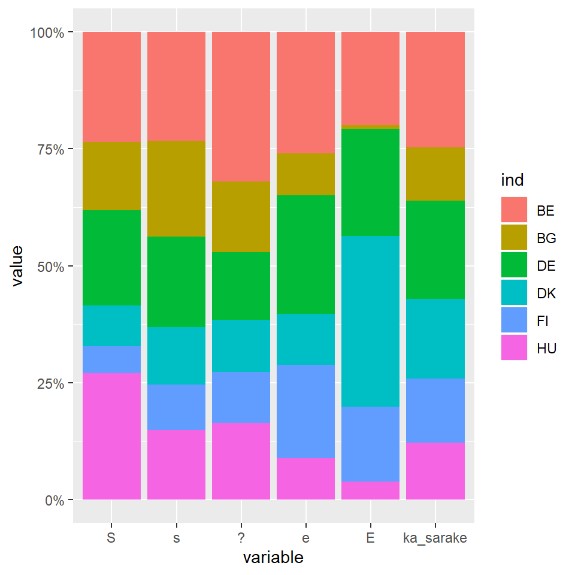

```r
#mutkikas kuvan piirto - sarakeprofiilit vertailussa
#ggplot vaatii df-rakenteen ja 'long data' - muotoon
##https://stackoverflow.com/questions/9563368/create-stacked-barplot-where-each-stack-is-scaled-to-sum-to
#
# käytetään ca - tuloksia
apu1test <- (simpleCA2$N)
colnames(apu1test) <- c("S", "s", "?", "e", "E")
rownames(apu1test) <- c("BE", "BG", "DE", "DK", "FI", "HU")
apu1_dftest <- as.data.frame(apu1test)
#lasketan rivien reunajakauma
apu1_dftest$ka_sarake <- rowSums(apu1_dftest)
#muokataan 'long data' - muotoon
apu1b_dftest <- melt(cbind(apu1_dftest, ind = rownames(apu1_dftest)), id.vars = c('ind'))

ggplot(apu1b_dftest, aes(x = variable, y = value, fill = ind)) +
         geom_bar(position = "fill", stat ="identity") +
         scale_y_continuous(labels = percent_format())
```

```r
#apu1b_df
```

**zxy** Massat saa mukaan vaikka viittaamalla frekvenssitauluun (4.9.2018)

Riviprofiilikuva toimii, mutta vaatii vielä viilausta (18.9.2018)

[figure not shown]

```r
# riviprofiilit ja keskiarvorivi -  18.9.2018
apu2_df <- as.data.frame(apu1)
apu2_df <- rbind(apu2_df, ka_rivi = colSums(apu2_df))

#apu2_df
#str(apu2_df)
## typeof(apu2_df) # what is it?
## class(apu2_df) # what is it? (sorry)
## storage.mode(apu2_df) # what is it? (very sorry)
## length(apu2_df) # how long is it? What about two dimensional
## objects?
# attributes(apu2_df)

# temp1 <- cbind(apu2_df, ind = rownames(apu2_df))
# temp1
##muokataan 'long data' - muotoon
apu2b_df <- melt(cbind(apu2_df, ind = rownames(apu2_df)), id.vars = c('ind'))
#apu2b_df
#
#
#ggplot(apu2b_df, aes(x = value, y = ind, fill = variable)) +
#       geom_bar(position = "fill", stat ="identity") +
#       #coord_flip() +
#        scale_x_continuous(labels = percent_format())
#versio2 # perkele, tämä toimii! 18.9.2018
ggplot(apu2b_df, aes(x = ind, y = value, fill = variable)) +
       geom_bar(position = "fill", stat ="identity") +
       coord_flip() +
        scale_y_continuous(labels = percent_format())
```

Ja sama testaus kuin sarakeprofiilikuvilla

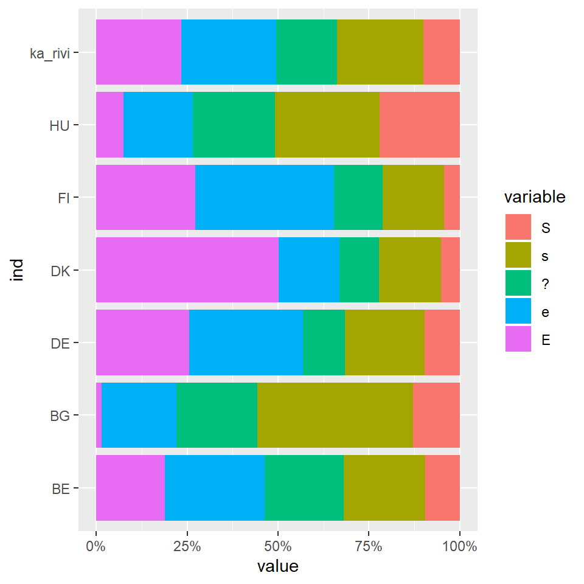

```r
# riviprofiilit ja keskiarvorivi -  18.9.2018
apu2_dftest <- as.data.frame(apu1test)
apu2_dftest <- rbind(apu2_dftest, ka_rivi = colSums(apu2_dftest))

#apu2_df
#str(apu2_df)
## typeof(apu2_df) # what is it?
## class(apu2_df) # what is it? (sorry)
## storage.mode(apu2_df) # what is it? (very sorry)
## length(apu2_df) # how long is it? What about two dimensional
## objects?
# attributes(apu2_df)

# temp1 <- cbind(apu2_df, ind = rownames(apu2_df))
# temp1
##muokataan 'long data' - muotoon
apu2b_dftest <- melt(cbind(apu2_dftest, ind = rownames(apu2_dftest)), id.vars = c('ind'))
#apu2b_df
#
#
#ggplot(apu2b_df, aes(x = value, y = ind, fill = variable)) +
#       geom_bar(position = "fill", stat ="identity") +
#       #coord_flip() +
#        scale_x_continuous(labels = percent_format())
#versio2 # perkele, tämä toimii! 18.9.2018
ggplot(apu2b_dftest, aes(x = ind, y = value, fill = variable)) +
       geom_bar(position = "fill", stat ="identity") +
       coord_flip() +
        scale_y_continuous(labels = percent_format())
```

**Graafinen analyysi ja R**

Käytänön neuvoja data-analyysiin, kuulunee tekstiin, vai meneekö “ohjelmistoympäristö” -liitteeseen? Tärkeä juttu!

Kuvasuhteen saa oikeaksi, kun avaa g-ikkunan (X11()) ja sitten plot. Voi tallentaa pdf-muodossa grafiikkaikkunasta, ja ladata outputiin knitr-vaiheessa. Parempi tulostaa kuvatdsto pdf-ajurilla, jos lopulliseen versioon joutuu näin tekemään (13.5.2018 ). Tämä voi olla järkevä tapa analyysivaiheessa? Teksti kopsattu alla olevasta koodilohkosta.